# Analysis of trends and agricultural drivers of farmland bird declines in North America: A review - ScienceDirect

[figure not shown]

[figure not shown]

[figure not shown]

## [Agriculture, Ecosystems & Environment](https://www.sciencedirect.com/journal/agriculture-ecosystems-and-environment)

[Volume 254](https://www.sciencedirect.com/journal/agriculture-ecosystems-and-environment/vol/254/suppl/C), 15 February 2018, Pages 244-254

# Review Analysis of trends and agricultural drivers of farmland bird declines in North America: A review

[R.L.Stanton<sup>a</sup>](https://www.sciencedirect.com/science/article/pii/S016788091730525X#!)[C.A.Morrissey<sup>a</sup><sup>c</sup>](https://www.sciencedirect.com/science/article/pii/S016788091730525X#!)[R.G.Clark<sup>a</sup><sup>b</sup>](https://www.sciencedirect.com/science/article/pii/S016788091730525X#!)

https://doi.org/10.1016/j.agee.2017.11.028[Get rights and content](https://s100.copyright.com/AppDispatchServlet?publisherName=ELS&contentID=S016788091730525X&orderBeanReset=true)

## Highlights

**•**

Grassland and farmland birds have experienced severe declines in recent decades.

**•**

Drivers are habitat loss, mowing/harvesting, disturbance, pesticides, food supply.

**•**

Pesticides and mowing/harvesting have the most consistently negative effects.

## Abstract

Globally, agriculture has intensified during the past 50 years due to increased mechanization, changes in the timing of farming operations, grassland conversion to cropland, and increased agrochemical inputs. Birds associated with farmlands and grasslands in North America have experienced severe declines over the last several decades, prompting the need for a comprehensive review of the drivers, mechanisms and magnitude of effects on bird populations. Here we evaluated changes in North American farmland bird populations over time and conducted a systematic review and analysis of the published literature to identify the major causes. Based on North American [Breeding Bird](https://www.sciencedirect.com/topics/earth-and-planetary-sciences/breeding-bird) Survey data, populations of 57 of 77 (74%) farmland-associated species decreased from 1966 to 2013. Multiple species exhibited highly congruent declines during the 1960s-1980s − a period with rapid changes in farming practices to low tillage systems, heavy pesticide use and widespread conversion of grassland habitat to cropland. The most severe declines occurred in aerial insectivorous birds (average change of −39.5% from 1966 to 2013), followed by grassland (‐20.8%) and shrubland (‐16.5%) [bird species](https://www.sciencedirect.com/topics/earth-and-planetary-sciences/bird-specie). Direct agricultural drivers impacting bird abundance, survival, and reproduction include loss of natural habitats, interference from farming equipment, and direct mortality or sublethal effects from pesticide exposure. Subtle interference with behaviour or physiology are reported through indirect drivers such as reduced food supplies, sublethal pesticide toxicity, [habitat fragmentation](https://www.sciencedirect.com/topics/agricultural-and-biological-sciences/forest-fragmentation) and alteration, and disturbance. Indirect effects are likely significant for many species, particularly aerial [insectivores](https://www.sciencedirect.com/topics/earth-and-planetary-sciences/insectivore), but detailed mechanistic studies are lacking. Our review of 122 studies found that pesticides (42% of all studies), followed by habitat loss or alterations (27%), were most predominant in negatively affecting farmland birds, with pesticides (93% negative) and mowing/harvesting (81% negative) having the most consistently negative effects. Modifications to farmland management such as reducing pesticide inputs through [integrated pest management](https://www.sciencedirect.com/topics/earth-and-planetary-sciences/integrated-pest-management) and maintaining or restoring uncultivated field margins and native habitat could positively influence farmland birds without significantly reducing agricultural crop yields.

## Keywords

Aerial insectivores

Agricultural intensification

Avian declines

Habitat loss

Farmland birds

Grassland birds

Pesticides

## 1. Introduction: agricultural intensification and birds as indicators of change

Table 1. Statistics showing decadal changes in agriculture in Canada, 1966–2016, and the United States, 1964–2007.

| Canada | 1966 | 1976 | 1986 | 1996 | 2006 | 2016 |
| --- | --- | --- | --- | --- | --- | --- |
| Total farm area (ha) | 70,464,083 | 68,660,645 | 67,825,757 | 68,054,956 | 67,586,741 | 64,232,948 |
| Total number of farms | 430,503 | 338,552 | 293,089 | 276,548 | 229,373 | 193,492 |
| Average farm size (ha) | 163 | 202 | 231 | 246 | 295 | 315 |
| % of farm area in crops | 39.7 | 41.3 | 48.9 | 51.3 | 53.1 | 60.0 |

| United States | 1964 | 1974 | 1987 | 1997 | 2007 | 2017 |
| --- | --- | --- | --- | --- | --- | --- |
| Total farm area (ha) | 449,268,645 | 411,577,583 | 390,307,414 | 386,374,629 | 373,158,947 | NA |
| Total number of farms | 3,157,857 | 2,314,013 | 2,087,759 | 2,215,876 | 2,204,792 | NA |
| Average farm size (ha) | 142 | 178 | 187 | 174 | 169 | NA |
| % of farm area in crops | 39.1 | 43.3 | 46.0 | 46.6 | 44.1 | NA |

(source: Canadian Census of Agriculture [Statistics Canada, 2006, Statistics Canada, 2016], USDA Census of Agriculture [US Department of Agriculture USDA, 1982, USDA, 2012]).

To our knowledge, relationships between agriculture and avian declines have not been comprehensively reviewed for North America, with few exceptions (see Rodenhouse et al., 1995; Lacher et al., 2010). Therefore, our goal was to review and evaluate observational and experimental support for linkages and potential mechanisms involved in agriculturally-driven avian declines in North America.

## 2. Methods

### 2.1. Population trends of farmland birds

We reviewed available data on the population trends and agricultural effects for 77 North American breeding [bird species](https://www.sciencedirect.com/topics/earth-and-planetary-sciences/bird-specie) inhabiting farmlands. The list of “grassland birds” was defined by the North American [Breeding Bird](https://www.sciencedirect.com/topics/earth-and-planetary-sciences/breeding-bird) Survey (BBS) (n = 28) and expanded to include species reported as farmland-dependent (Murphy, 2003) (n = 60, with some overlap with BBS species). Each species was categorized by foraging habitat into aerial (n = 6), grassland (n = 42) or shrubland (n = 29) based on Murphy (2003). Species with obligate dependence on [aquatic habitats](https://www.sciencedirect.com/topics/agricultural-and-biological-sciences/aquatic-habitat) for nesting or foraging, such as [Anseriformes](https://www.sciencedirect.com/topics/agricultural-and-biological-sciences/anseriformes), or closed forests, were excluded. Population changes were determined for each species using published annual BBS trend data from 1966 to 2013 (Sauer et al., 2014; Table 2). To construct figures, we determined the percent change per year based on the average annual trend for each decade (i.e. 1966–1975, 1976–1985, etc.; e.g. all years from 1966 to 1975 were assigned the average decadal trend). We then used these estimates to project population trends by habitat group (aerial, grassland or shrubland species) as well as convergence and divergence of individual species trends in response to historical changes in agriculture by decade.

Table 2. Summary of average yearly population trends (with 2.5 and 97.5% credible intervals (CI)) for 77 farmland-associated bird species in Canada and the United States based on North American Breeding Bird Survey estimates, 1966–2013. Species are grouped (guilds) by aerial insectivores, and grassland and shrubland birds. Within guilds, species are ranked in order of survey-wide trend estimates from positive to negative.

| Empty Cell | Empty Cell Species | Average trend per year<sup>a</sup> Canada (CI)<sup>b</sup> | Average trend per year<sup>a</sup> United States (CI) | Average trend per year<sup>a</sup> Survey-wide (CI) |
| --- | --- | --- | --- | --- |
| Aerial | Cliff swallow (*Petrochelidon pyrrhonota*) | **−4.66 (−8.83, −2.82)** | **1.20 (0.54, 1.63)** | 0.25 (−2.24, 0.88) |
|  | Purple martin (*Progne subis*) | −1.15 (−2.56, 0.22) | **−0.86 (−3.27, −0.43)** | **−0.87 (−3.24, −0.45)** |
|  | Barn swallow (*Hirundo rustica*) | **−3.67 (−4.06, −3.33)** | **−0.51 (-0.64, −0.38)** | **−1.27 (−1.44, −1.12)** |
|  | Tree swallow (*Tachycineta bicolor*) | **−2.23 (−2.85, −1.75)** | 0.09 (−0.32, 0.42) | **−1.37 (−1.91, −1.03)** |
|  | Common nighthawk (*Chordeiles minor*) | **−4.05 (−10.01, −2.47)** | **−1.88 (−2.61, −1.54)** | **−2.06 (−7.16, −1.69)** |
|  | Bank swallow (*Riparia riparia*) | **−8.05 (−9.67, −6.13)** | **−2.30 (−4.17, −0.80)** | **−5.83 (−7.37, −4.38)** |
|  | **Guild average** | −3.97 | −0.71 | −1.86 |
| Grassland | Greater prairie-chicken (*Tympanuchus cupido*) | NA | **4.13 (−1.19, 8.40)** | **4.13 (−1.19, 8.40)** |
|  | Turkey vulture (*Cathartes aura*) | 7.80 (3.61, 9.83) | **2.33 (1.99, 2.69)** | **2.38 (2.05, 2.74)** |
|  | Eastern bluebird (*Sialia sialis*) | **2.02 (0.19, 3.37)** | **1.92 (1.69, 2.13)** | **1.92 (1.69, 2.13)** |
|  | Barn owl (*Tyto alba*) | NA | 1.62 (−1.71, 3.96) | 1.62(−1.71, 3.96) |
|  | Carolina wren (*Thryothorus ludovicianus*) | 4.87 (−0.66, 10.79) | **1.35 (1.15, 1.53)** | **1.35 (1.15, 1.53)** |
|  | Sedge wren (*Cistothorus platensis*) | 0.86 (−2.13, 2.68) | 0.85 (−0.14, 1.67) | 0.81 (−0.94, 1.71) |
|  | Ferruginous hawk (*Buteo regalis*) | 0.08 (−2.35, 2.26) | **0.92 (0.06, 1.72)** | 0.73 (−0.20, 1.52) |
|  | Upland sandpiper (*Bartramia longicauda*) | −0.29 (−2.08, 0.94) | **0.60 (0.10, 1.10)** | 0.49 (−0.02, 0.96) |
|  | Wilson’s snipe (*Gallinago delicata*) | 0.52 (−0.17, 1.17) | −0.18 (−0.64, 0.32) | 0.34 (−0.19, 0.83) |
|  | Long-billed curlew (*Numenius americanus*) | −0.56 (−1.90, 0.85) | 0.65 (−1.14, 1.62) | 0.34 (−1.17, 1.20) |
|  | Sharp-tailed grouse (*Tympanuchus phasianellus*) | −0.73 (−3.04, 1.17) | 0.76 (−1.55, 2.72) | 0.16 (−1.79, 1.67) |
|  | House wren (*Troglodytes aedon*) | −0.09 (−0.52, 0.32) | −0.15 (-0.03, 0.31) | 0.07 (−0.12, 0.24) |
|  | Mourning dove (*Zenaida macroura*) | **0.65 (0.22, 1.09)** | **−0.42 (−0.55, −0.29)** | **−0.38 (−0.50, −0.26)** |
|  | Dickcissel (*Spiza americana*) | 20.2 (−9.29, 75.75) | **−0.62 (−1.13, −0.20)** | **−0.62 (−1.13, −0.20)** |
|  | Brown-headed cowbird (*Molothrus ater*) | **−1.59 (−2.51, −1.11)** | **−0.50 (−0.67, −0.35)** | **−0.74 (−1.09, −0.58)** |
|  | Vesper sparrow (*Pooecetes gramineus*) | **−0.49 (−1.02, −0.01)** | **−1.21 (−1.60, −0.90)** | **−0.89 (−1.24, −0.61)** |
|  | Lark sparrow (*Chondestes grammacus*) | 1.63 (−0.54, 3.65) | **−0.94 (-1.35, −0.51)** | **−0.94 (−1.34, −0.50)** |
|  | Red-winged blackbird (*Agelaius phoeniceus*) | **−0.91 (−1.29, −0.54)** | **−0.99 (−1.12, −0.86)** | **−0.98 (−1.09, −0.85)** |
|  | Common yellowthroat (*Geothlypis trichas*) | **−1.10 (−1.65, −0.61)** | **−0.96 (−1.06, −0.86)** | **−1.02 (−1.27, −0.81)** |
|  | Burrowing owl (*Athene cunicularia*) | −6.00 (−10.60, −1.33) | **−1.01 (−2.15, −0.14)** | **−1.08 (−2.19, −0.22)** |
|  | Eastern kingbird (*Tyrannus tyrannus*) | **−1.81 (−2.30, −1.37)** | **−0.96 (−1.14, −0.79)** | **−1.13 (−1.32, −0.96)** |
|  | Henslow's sparrow (*Ammodramus henslowii*)* | **−3.63 (−10.14, 2.78)** | **−1.13 (−2.38, −0.02)** | **−1.14 (−2.38, −0.02)** |
|  | Killdeer (*Charadrius vociferous*) | **−3.18 (−4.33, −2.70)** | **−0.56 (−0.74, −0.37)** | **−1.20 (−1.72, −0.99)** |
|  | Northern harrier (*Circus cyaneus*) | **−2.19 (−3.06, −1.49)** | **−0.59 (−1.11, −0.13)** | **−1.21 (−1.74, −0.81)** |
|  | Savannah sparrow (*Passerculus sandwichensis*) | **−1.28 (−1.65, −0.90)** | **−1.25(−1.66, −0.90)** | **−1.27 (−1.58, −0.97)** |
|  | Western meadowlark (*Sturnella neglecta*) | **−2.13 (−2.63, −1.65)** | **−1.20 (−1.51, −0.92)** | **−1.30 (−1.59, −1.05)** |
|  | American kestrel (*Falco sparverius*) | **−2.71 (−4.43, −1.58)** | **−1.10 (−1.37, −0.86)** | **−1.65 (−2.53, −1.22)** |
|  | Cassin's sparrow (*Peucaea cassinii*) | NA | **−1.97 (−3.60, −0.99)** | **−1.97 (−3.60, −0.99)** |
|  | Bobolink (*Dolichonyx oryzivorus*) | **−3.65 (−5.07, −3.18)** | **−1.00 (−1.38, −0.59)** | **−2.04 (−3.07, −1.70)** |
|  | Le Conte's sparrow (*Ammodramus leconteii*) | **−2.27 (−3.73, −0.69)** | 1.33 (−0.84, 3.42) | **−2.18 (−3.62, −0.71)** |
|  | Horned lark (*Eremophila alpestris*) | **−4.81 (−5.77, −3.88)** | **−1.76 (−2.11, −1.23)** | **−2.38 (−2.82, −1.92)** |
|  | Grasshopper sparrow (*Ammodramus savannarum*) | −1.21 (−8.34, 1.83) | **−2.82 (−3.42, −2.33)** | **−2.83 (−3.76, −2.32)** |
|  | Baird's sparrow (*Ammodramus bairdii*) | **−2.65 (−4.76, −0.58)** | **−3.51 (−5.22, −1.09)** | **−2.93 (−4.52, −1.31)** |
|  | Mountain plover (*Charadrius montanus*)* | NA | **−3.11 (−7.82, −0.80)** | **−3.11 (−7.82, −0.80)** |
|  | Short-eared owl (*Asio flammeus*) | **−4.98 (−10.78, −1.17)** | **−2.21 (−5.31, −0.10)** | **−3.26 (−7.71, −1.11)** |
|  | Eastern meadowlark (*Sturnella magna*) | **−3.21 (−3.67, −2.77)** | **−3.35 (−3.73, −3.08)** | **−3.34 (−3.71, −3.08)** |
|  | Loggerhead shrike (*Lanius ludovicianus*) | **−2.88 (−4.22, −1.52)** | **−3.21 (−3.50, −2.91)** | **−3.49 (−3.49, −2.91)** |
|  | Sprague's pipit (*Anthus spragueii*)** | **−3.87 (−5.24, −2.64)** | −1.05 (−3.24, 1.15) | **−3.51 (−4.83, −2.34)** |
|  | Northern bobwhite (*Colinus virginianus*)* | −21.4 (−25.97, −17.12) | **−4.08 (-4.38, −3.84)** | **−4.08 (−4.38, −3.84)** |
|  | Lark bunting (*Calamospiza melanocorys*) | **−6.41 (−10.62, −1.71)** | **−4.03 (−6.12, −2.38)** | **−4.10 (−6.12, −2.38)** |
|  | Chestnut-collared longspur (*Calcarius ornatus*)* | **−5.49 (−7.04, −3.73)** | **−3.65 (−4.57, −2.66)** | **−4.35 (−5.30, −3.33)** |
|  | McCown's longspur (*Rhynchophanes mccownii*) | **−8.24 (−11.67, −3.76)** | −0.99 (−3.41, 1.47) | **−6.20 (−8.90, −2.85)** |
|  | **Guild average** | −1.60 | −0.83 | −1.21 |
| Shrub | Red-tailed hawk (*Buteo jamaicensis*) | 0.51 (−0.07, 1.04) | **1.78 (1.59, 1.96)** | **1.46 (1.23, 1.66)** |
|  | Blue grosbeak (*Guiraca caerulea*) | NA | **0.81 (0.53, 1.02)** | **0.81 (0.53, 1.02)** |
|  | White-eyed vireo (*Vireo griseus*) | NA | **0.51 (0.30, 0.71)** | **0.51 (0.30, 0.71)** |
|  | Eastern phoebe (*Sayornis phoebe*) | **−1.46 (−2.90, −0.27)** | **1.25 (1.06, 1.43)** | 0.50 (−0.20, 0.91) |
|  | Northern cardinal (*Cardinalis cardinalis*) | **3.89 (3.15, 4.69)** | **0.33 (0.24, 0.42)** | **0.34 (0.25, 0.43)** |
|  | American crow (*Corvus brachyrhynchos*) | −0.17 (−0.51, 0.15) | **0.35 (0.24, 0.45)** | **0.16 (0.00, 0.29)** |
|  | American robin (*Turdus migratorius*) | −0.10 (−0.30, 0.09) | **0.32 (0.23, 0.40)** | **0.14 (0.04, 0.24)** |
|  | Cedar waxwing (*Bombycilla cedrorum*) | −0.52 (−1.62, 0.24) | **0.69 (0.28, 1.02)** | −0.04 (−0.90, 0.46) |
|  | Gray catbird (*Dumetella carolinensis*) | **−0.41 (−0.77, −0.06)** | −0.04 (0.15, 0.07) | −0.09 (−0.19, 0.02) |
|  | American goldfinch (*Carduelis tristis*) | **−0.62 (−1.04, −0.25)** | 0.07 (−0.11, 0.23) | **−0.18 (−0.38, −0.00)** |
|  | Yellow warbler (*Dendroica petechia*) | **−0.76 (−1.19, −0.38)** | **−0.20 (−0.39, −0.01)** | **−0.53 (−0.82, −0.29)** |
|  | Blue-winged warbler (*Vermivora pinus*) | 6.87 (3.07, 10.92) | −0.64 (−1.28, 0.13) | −0.58 (−1.21, 0.18) |
|  | Northern mockingbird (*Mimus polyglottos*) | 0.71 (−1.69, 2.87) | **−0.59 (−0.75, −0.43)** | **−0.59 (−0.75, −0.43)** |
|  | Chipping sparrow (*Spizella passerina*) | **−1.19 (−1.68, −0.76)** | 0.07 (−0.11, 0.21) | **−0.59 (−0.94, −0.34)** |
|  | Yellow-breasted chat (*Icteria virens*) | 1.68 (−2.87, 6.03) | **−0.67 (−0.87, −0.47)** | **−0.67 (−0.87, −0.47)** |
|  | Song sparrow (*Melospiza melodia*) | **−1.06 (−1.39, −0.78)** | **−0.48 (−0.61, −0.37)** | **−0.74 (−0.90, −0.59)** |
|  | Indigo bunting (*Passerina cyanea*) | **0.89 (0.09, 1.59)** | **−0.80 (−0.89, −0.70)** | **−0.78 (−0.87, −0.69)** |
|  | Orchard oriole (*Icterus spurius*) | 4.76 (2.18, 6.63) | **−0.85 (−1.14, −0.60)** | **−0.84 (−1.12, −0.59)** |
|  | Brown thrasher (*Toxostoma rufum*) | **−1.13 (−1.71, −0.59)** | **−1.02 (−1.15, −0.89)** | **−1.02 (−1.16, −0.90)** |
|  | Baltimore oriole (*Icterus galbula*) | **−3.20 (−4.00, −2.52)** | **−0.75 (−1.00, −0.55)** | **−1.35 (−1.70, −1.09)** |
|  | Eastern towhee (*Pipilo erythrophthalmus*) | −0.87 (−2.10, 0.32) | **−1.38 (−1.52, −1.25)** | **−1.38 (−1.52, −1.25)** |
|  | Willow flycatcher (*Empidonax traillii*) | **−1.80 (−2.51, −1.05)** | **−1.25 (−1.72, −0.86)** | **−1.46 (−1.86, −1.08)** |
|  | Chestnut-sided warbler (*Dendroica pensylvanica*) | **−1.64 (−2.49, −0.92)** | **−0.92 (−1.16, −0.68)** | **−1.48 (−2.18, −0.91)** |
|  | Yellow-billed cuckoo (*Coccyzus americanus*) | −1.25 (−2.87, 0.49) | **−1.75 (−1.99, −1.50)** | **−1.75 (−1.99, −1.50)** |
|  | Common grackle (*Quiscalus quiscula*) | **−0.80 (−1.22, −0.43)** | **−1.85 (−2.01, −1.69)** | **−1.76 (−1.91, −1.60)** |
|  | Prairie warbler (*Dendroica discolor*) | NA | **−1.96 (−2.30, −1.62)** | **−1.96 (−2.30, −1.62)** |
|  | Field sparrow (*Spizella pusilla*) | **−1.95 (−6.59, −1.16)** | −2.35 (−38.74, −2.17) | −2.36 (−38.73, −2.17) |
|  | Red-headed woodpecker (*Melanerpes erythrocephalus*)* | **−2.50 (−4.32, −0.84)** | **−2.48 (−2.81, −2.15)** | **−2.48 (−2.81, −2.16)** |
|  | Black-billed cuckoo (*Coccyzus erythropthalmus*) | −2.04 (−5.59, 0.12) | **−3.25 (−8.03, −2.52)** | **−2.73 (−7.56, −1.42)** |
|  | **Guild average** | −0.16 | −0.59 | −0.74 |

*Near-threatened.

**Vulnerable.

**a**

Trends with sufficient sample sizes and CIs that do not contain 0 (and therefore are considered significant) are indicated in bold.

**b**

Trends for species either not present or not surveyed in Canada are represented by “NA”.

### 2.2. Agricultural drivers of farmland bird declines

We hypothesized all potential drivers of agriculturally-mediated farmland declines with direct and indirect effects on abundance, reproduction, and survival and classified these as follows: 1) habitat loss and fragmentation through land conversion, 2) mowing and harvesting operations, 3) livestock grazing disturbance, 4) pesticide lethal and sublethal toxicity, and 5) changes in food supply (Fig. 1). While previous reviews on farmland birds in Europe (e.g. Tucker and Evans, 1997) contained information on all potential threats, our review focuses on those related to agriculture. This review excludes deliberate lethal killing practices to reduce crop damage, though these actions may have contributed to declines in bird species perceived as [crop pests](https://www.sciencedirect.com/topics/earth-and-planetary-sciences/crop-pest) (e.g. rusty blackbirds [*Euphagus carolinus*, Greenberg et al., 2011], dickcissels [*Spiza americana*, Basili and Temple, 1999], bobolinks [Renfrew and Saavedra, 2007]).

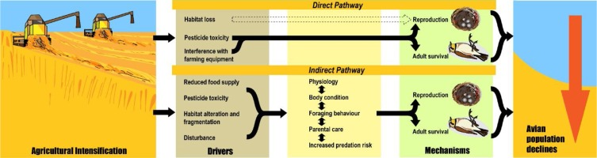

1. [Download : Download high-res image (382KB)](https://ars.els-cdn.com/content/image/1-s2.0-S016788091730525X-gr1_lrg.jpg)
2. [Download : Download full-size image](https://ars.els-cdn.com/content/image/1-s2.0-S016788091730525X-gr1.jpg)

Fig. 1. Potential direct and indirect effect pathways of agricultural intensification effects on avian population declines. Reproduction includes mortality or impairment at egg and nestling/juvenile stages, whereas survival represents adult survival. Although shown separately, direct and indirect effects on reproduction and survival could act simultaneously.

Direct and indirect threats of agricultural intensification are present on breeding and wintering grounds, but we emphasize impacts on the [breeding grounds](https://www.sciencedirect.com/topics/agricultural-and-biological-sciences/breeding-site) in Canada and the US. For each threat, there are direct effects of agricultural intensification on reproduction and survival of birds inhabiting farmland habitats, in addition to complex indirect effects. Direct effects are those that result in mortality or destruction of eggs, young, or adults, triggering reductions in reproductive success and survival. Indirect effects also result in mortality or destruction of eggs, young, or adults, but occur through an intermediary action(s) (Fig. 1).

To determine the extent of agricultural impacts on [avian species](https://www.sciencedirect.com/topics/agricultural-and-biological-sciences/avian-species), a literature search was completed using all years in Web of Science™ (accessed September 2013 to February 2017). Searches were limited to the US and Canada as data for Mexico were scarce, and search terms included “birds”, “agriculture”, and [effect], where [effect] was either conservation, [fertilizer](https://www.sciencedirect.com/topics/earth-and-planetary-sciences/fertiliser), field margins, food supply, foraging, grazing, [habitat fragmentation](https://www.sciencedirect.com/topics/agricultural-and-biological-sciences/forest-fragmentation), habitat loss, herbicides, [insecticides](https://www.sciencedirect.com/topics/earth-and-planetary-sciences/insecticide), management, mowing, pesticides, physiology, or predation, as well as [species] and “agriculture” or “agricultural”, with [species] including the 77 species listed in Table 2. A summary of available published data for the 77 species organized by driver is available in Appendix A. Factors for inclusion in the quantitative analysis included studies that met the following criteria: 1) results supported by p-values for an identified species or set of species, 2) reported one or more of the “effect parameters” (below), and 3) evaluated one or more of the drivers (habitat loss and fragmentation, pesticide toxicity, mowing and harvesting, etc.). These data were individually reviewed to identify the number of unique species and studies for each driver, whether the effect was positive (significant positive response), neutral (no effect) or negative (significant negative response) on the following “effect parameters” including survival, reproduction, abundance, density, occurrence, behaviour, physiology, and [predation risk](https://www.sciencedirect.com/topics/earth-and-planetary-sciences/predation-risk). For presentation purposes, we grouped those studies reporting abundance, density and occurrence into a single category.

## 3. Declining trends of North American farmland birds

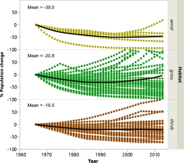

1. [Download : Download high-res image (345KB)](https://ars.els-cdn.com/content/image/1-s2.0-S016788091730525X-gr2_lrg.jpg)
2. [Download : Download full-size image](https://ars.els-cdn.com/content/image/1-s2.0-S016788091730525X-gr2.jpg)

Fig. 2. Population trends of 77 North American farmland bird species based on data collected by the North American Breeding Bird Survey, 1966–2013 (Sauer et al., 2014). Dotted lines represent % change in individual species populations based on the average annual trend for each decade (1966–1975, 1976–1985, etc.). The solid black line and mean estimate represent the average trend for all species in each habitat guild over the duration of study period 1966–2013.

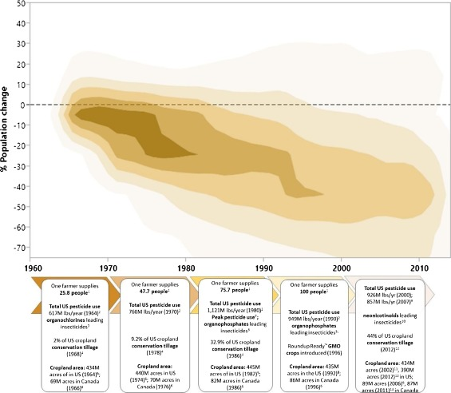

1. [Download : Download high-res image (504KB)](https://ars.els-cdn.com/content/image/1-s2.0-S016788091730525X-gr3_lrg.jpg)
2. [Download : Download full-size image](https://ars.els-cdn.com/content/image/1-s2.0-S016788091730525X-gr3.jpg)

Fig. 3. Contour density plot showing population trends for 77 North American farmland bird species (grassland, shrub and aerial insectivores) from 1966 to 2013, based on the North American Breeding Bird Survey. Contours show data concentrations where trend data among species are converging (darker colours) or diverging (lighter colours). Data on bird trends are represented alongside the timing of key changes in agricultural practices through the decades (1960s-2010).

<sup>1</sup>https://www.agclassroom.org/gan/timeline/index.htm, <sup>2</sup>US EPA (2004), <sup>3</sup>Aspelin (2003), <sup>4</sup>;Schertz (1988), <sup>5</sup>US Department of Agriculture USDA (1982), <sup>6</sup> Statistics Canada (2006), <sup>7</sup>USDA (2014), <sup>8</sup>USDA (1992), <sup>9</sup>US EPA (2011), <sup>10</sup>Jeschke et al. (2011), <sup>11</sup>USDA, 2002, <sup>12</sup>USDA (2012), <sup>13</sup>Statistics Canada (2011).

## 4. Review of potential drivers of farmland bird declines

### 4.1. Habitat loss and fragmentation

Habitat loss has been described as a primary driver of agriculturally-mediated grassland bird declines (Herkert et al., 1996, Vickery et al., 1999, Brennan and Kuvlesky, 2005). From 1982 to 1997, 97,000 km<sup>2</sup> of grasslands were lost in the US, with most converted to agriculture (Samson et al., 2004), while approximately 75% of prairie grassland in Canada had been lost due to agriculture by 1993 (Downes et al., 2011). In areas that are particularly well suited for agricultural crops such as landscapes with flat topography and rich soils, grassland loss is even more profound, with less than 0.1% of native prairie remaining (Samson and Knopf, 1994). Only 4% of tallgrass prairie remains in North America (Steinauer and Collins, 1996), while <13% of the short-grass prairie and almost none of the tallgrass prairie remains intact in Canada (McLaughlin and Mineau, 1995). There has also been an estimated 70% loss of wetlands in the Prairie region of Canada (Canadian Wetland Inventory, 2008), with 84% of the loss attributed to agricultural drainage (Canadian Wildlife Service, 1991).

Widespread loss of grassland habitat usually produces fragmentation and isolation of remnant grasslands. Many farmland bird species are sensitive to edge effects or fragment size, so smaller, isolated grasslands are unlikely to sustain diverse bird communities (Helzer and Jelinski, 1999, Vickery et al., 1999, Kirk et al., 2011); however, effects of fragmentation on occurrence or abundance have been absent for many other species (Bayard and Elphick, 2010). Regardless, [habitat fragmentation](https://www.sciencedirect.com/topics/agricultural-and-biological-sciences/forest-fragmentation) can result in higher rates of [nest predation](https://www.sciencedirect.com/topics/earth-and-planetary-sciences/nest-predation). In prairie fragments <100 ha, 78–84% of all nests of four grassland birds (dickcissel, eastern meadowlark [*Sturnella* *[magna](https://www.sciencedirect.com/topics/earth-and-planetary-sciences/magnon)*], grasshopper sparrow [*[Ammodramus](https://www.sciencedirect.com/topics/agricultural-and-biological-sciences/ammodramus)* *savannarum*], and Henslow’s sparrow [*Ammodramus henslowii*]) were depredated, compared to 54–68% of nests in fragments >1000 ha (Herkert, 2003; also see Horn et al., 2005).

Avian species composition, abundance and diversity are influenced by compositional (i.e. number of landscape types) and configurational (i.e. complexity of the landscape) heterogeneity (Lindsay et al., 2013). Recent conversion of pastures and hayfields to [row cropping](https://www.sciencedirect.com/topics/agricultural-and-biological-sciences/row-cropping) in the US Midwest, along with altered cutting regimes, have resulted in unsuitable nesting habitat for several grassland species (Warner, 1994, Herkert et al., 1996). Even where pastures still exist, alfalfa [monocultures](https://www.sciencedirect.com/topics/earth-and-planetary-sciences/monoculture) have often replaced mixed stands of grasses and legumes that had previously provided birds with native-like prairie habitat (Graber and Graber, 1963, Warner, 1994). Field margins, forest patches and [hedgerows](https://www.sciencedirect.com/topics/earth-and-planetary-sciences/hedgerow) are important habitats for enhancing landscape complexity in agricultural landscapes, and providing essential [refugia](https://www.sciencedirect.com/topics/earth-and-planetary-sciences/refugium) for diverse insect communities (Dennis and Fry, 1992; Mineau and McLaughlin, 1996). Presence of hedgerows increases abundance and diversity of beneficial insect and bird species that can provide important ecosystem services (Jobin et al., 2001; Morandin et al., 2014), and native upland and wetland habitats have higher relative abundance and diversity of avian species than conventional, [minimum tillage](https://www.sciencedirect.com/topics/agricultural-and-biological-sciences/minimum-tillage), and organic farms (Shutler et al., 2000). Wetland loss and degradation can also indirectly influence reproduction of farmland birds. For example, the number of red-winged blackbird fledglings per nest increased with wetland size and abundance in the surrounding landscapes (Tozer et al., 2010), where higher fledging success was thought to result from greater food availability.

### 4.2. Pesticide use and toxicity

The latest estimates for 2011 and 2012 indicate [U.S.](https://www.sciencedirect.com/topics/earth-and-planetary-sciences/united-states-of-america) pesticide usage totaled over 498 million kg (1.1 billion lbs) annually, accounting for 16% of the world market (US EPA, 2017). It has been estimated that direct pesticide mortality accounts for the deaths of approximately 67–72 million birds in the US each year (Pimentel et al., 1992, Pimentel, 2005). This estimate conservatively assumes 10% mortality among exposed birds, and excludes mortality in wintering or migrating birds. In Canada, pesticide use contributes to an estimated 2.7 million cases of avian mortality annually (Calvert et al., 2013). Mixtures of multiple insecticide, fungicide and herbicide products are common in the environment to control various pests and weeds. Although rarely studied, exposure and effects to birds may be greater than expected based on toxicity to single compounds. Exposure to sixteen current-use pesticides (including carbamates, [organophosphates](https://www.sciencedirect.com/topics/earth-and-planetary-sciences/organophosphate), and neonicotinoids) was associated with changes in thyroid physiology important for growth of tree swallow (*[Tachycineta bicolor](https://www.sciencedirect.com/topics/agricultural-and-biological-sciences/tachycineta-bicolor)*) and [eastern bluebird](https://www.sciencedirect.com/topics/agricultural-and-biological-sciences/eastern-bluebird) (*Sialia sialis*) nestlings (Mayne et al., 2005). Insect bolus samples collected from nestling tree swallows contained traces of 25 different compounds, and at least 30% of samples contained at least 1 pesticide (Haroune, 2015). Although many herbicides are considered less toxic to birds, linuron exposure in American goldfinches (*[Carduelis](https://www.sciencedirect.com/topics/agricultural-and-biological-sciences/carduelis)* *tristis*) altered thyroid hormones and moult progression (Sughrue et al., 2008), and reduced mating success (Robertson et al., 1998).

Some of the most highly toxic pesticides to birds include the widely studied carbamates and organophosphates (Mineau et al., 1999, Mineau et al., 2005, Mineau, 2004) capable of killing thousands of birds at a time (Mineau, 1993). Canada’s Pest Management Regulatory Agency estimated between 109,000 and 958,000 birds were killed annually by carbofuran use on canola seeds alone (Segstro, 1998). Carbofuran was estimated to have killed 17 to 91 million [songbirds](https://www.sciencedirect.com/topics/earth-and-planetary-sciences/songbird) annually in the US during peak use on corn in the 1980s (Mineau, 2005). A 5% carbofuran granule can kill a house sparrow (*[Passer domesticus](https://www.sciencedirect.com/topics/agricultural-and-biological-sciences/passer-domesticus)*) within minutes, while individuals that consume one granule of terbufos (organophosphate) have a 50% survival probability (Mineau et al., 2005). The amount of organophosphate insecticides used in the U.S. has declined more than 70%, from an estimated 31 million kg (70 million lbs) in 2000 to 9 million kg (20 million lbs) in 2012 (US EPA, 2017) largely due to increased restrictions and rising popularity of newer products like [neonicotinoids](https://www.sciencedirect.com/topics/agricultural-and-biological-sciences/neonicotinoid).

Neonicotinoids (including imidacloprid, thiamethoxam, and clothianidin) are a class of systemic pesticides which now represent the most widely used insecticides worldwide (Jeschke et al., 2011), and are also of recent concern to farmland birds. Hallmann et al. (2014) reported a 3.5% average annual decline among 15 species of farmland birds in regions of the Netherlands where imidacloprid in water exceeded 20 ng/L. Applied primarily as a seed dressing, neonicotinoids comprise ∼25% of all insecticide use, and are licensed in more than 120 countries (Jeschke et al., 2011). A single corn kernel treated with imidacloprid, or just a few seeds treated with clothianidin or thiamethoxam, can potentially harm or kill a medium-sized bird such as a blue jay (*Cyanocitta cristata*), and as little as 1/10th of a neonicotinoid-treated corn kernel per day during egg-laying has been estimated to impair songbird reproduction (Mineau and Palmer, 2013). A captive study on white-crowned sparrows (*Zonotrichia leucophrys*) indicated ingestion of just 4–9 imidacloprid-treated seeds per day for 3 days can result in severe mass loss (17–25%) as well as temporary impairment of migratory orientation (Eng et al., 2017). Currently, there is a lack of studies looking at exposure and mortality in free-living birds that may consume neonicotinoid-treated seeds.

Survival and reproduction of birds can also be affected by sublethal pesticide toxicity through intermediate effects on behaviour, physiology, or condition. Sublethal exposure to pesticides such as the organophosphate acephate or chlorpyrifos can lead to altered songbird flight orientation (Vyas et al., 1995, Eng et al., 2017), while carbofuran can impair an individual’s ability to thermoregulate (Friend and Franson, 1999), or trigger ataxia (loss of control of body movements), dyspnea (labored breathing), immobility, and opisthotonos (muscle spasms leading to arching of back) (Hudson et al., 1984), all of which may increase vulnerability to predation and starvation.

Parental care is also sensitive to pesticides. Nestling tree swallows exhibited significant increases in begging following an application of azinphos-methyl and carbaryl insecticides in apple orchards, while parents reduced the number of feeding trips to the nest following a second application (Bishop et al., 2000). Likewise, European starlings (*[Sturnus vulgaris](https://www.sciencedirect.com/topics/agricultural-and-biological-sciences/sturnus-vulgaris)*) dosed with dicrotophos, had fewer feeding trips and lower chick mass gains within 12–24 h after dosing (Grue et al., 1982). Even if responses are temporary, such short-term effects could lower reproductive success, first year or adult survival.

### 4.3. Mowing and harvesting operations

Mechanization has increased over recent decades, and mowing, tilling, seeding, and harvesting are sources of direct avian mortality and nest destruction (Nocera et al., 2005, Shustack et al., 2010). Farm machinery used for soybean planting caused losses of 24.4% of 114 nests from a variety of grassland bird species; a 2-week delay in planting to early June would allow all destroyed nests to complete the nesting cycle, although soybean yields decrease for every day planting is delayed (VanBeek et al., 2014). Higher nest density was found in no-till corn and soybean fields than tilled fields (Basore et al., 1986), as was greater species richness and abundance (Castrale, 1985, Walk et al., 2010) as denser vegetation in these fields is hypothesized to lower [predation risk](https://www.sciencedirect.com/topics/earth-and-planetary-sciences/predation-risk) (VanBeek et al., 2014).

Typically, nest destruction from tilling, seeding, or harvesting is less severe than that from mowing, as tilling and seeding occur before many species have established nests, and harvesting occurs after nestlings have already fledged. In contrast, mowing operations can occur repeatedly, and often overlap with the breeding season (Tews et al., 2013), so the frequency and timing of mowing of hayfields can influence the relative impact on birds. Since the 1950s, the median date of mowing has advanced by 14–21 days, resulting in an overlap with peak nesting for farmland birds in many regions (Martin and Gavin, 1995, Herkert, 1997), likely due to a shift from native warm-season to exotic cool-season grasses that produce higher biomass earlier in summer (Giuliano and Daves, 2002). Birds breeding in warm-season cultivars experience greater nest success (measured as proportion of successful nests per field) and fledge rates compared to those in cool-season grasses, as a result of lower nest destruction and predation rates (Giuliano and Daves, 2002). Vesper sparrow nest success was significantly higher in wet seasons compared to dry seasons due to delayed (∼30 days) harvests in wet years (Perritt and Best, 1989).

Indirect effects of mowing and haying can affect reproduction and survival of farmland nesting birds (Diemer and Nocera, 2016). In grasshopper sparrows, 8.5% of nest failures resulted from direct interference with mowing equipment, whereas 67% failed due to subsequent predation (Giuliano and Daves, 2002). Nests that survive haying are often abandoned or destroyed by predators (Perritt and Best, 1989, Bollinger et al., 1990). In regions of Vermont and New York, 100% of active bobolink nests and 99% of active savannah sparrow (*[Passerculus sandwichensis](https://www.sciencedirect.com/topics/agricultural-and-biological-sciences/passerculus-sandwichensis)*) nests failed during early haying operations (Perlut et al., 2006), mainly due to higher nest predation. Leaving uncut patches for nesting birds, or delaying the timing of haying, may be a promising conservation strategy to reduce the effect of harvesting disturbance on farmland birds.

### 4.4. Grazing disturbance

Livestock grazing can result in increased predation risk, degradation of nesting habitat, or trampling of nests by cattle (Bleho et al., 2014), as well as rare instances of apparent predation by cattle (Nack and Ribic, 2005), but is highly dependent on species and region. Grazing can also benefit some species of grassland songbirds by influencing vegetation structure to create more suitable nesting habitat for short grass specialists (Fondell and Ball, 2004). Moderate levels of grazing provided suitable habitat for Henslow’s and grasshopper sparrows in New York (Smith, 1997), while in Illinois, light late-season grazing resulted in lower density of Henslow’s sparrow, but higher density of dickcissels, eastern meadowlarks, and grasshopper sparrows (Walk and Warner, 2000). The same variation in response to grazing exists for nest success. While some studies have found reduced nest success as a result of grazing (Shochat et al., 2005, Sutter and Ritchison, 2005), others found no difference between grazed and ungrazed areas (Zimmerman, 1996, Klute et al., 1997). A review of nest trampling rates by Bleho et al. (2014) reported that only 1.5% of 9132 nests across 9 ecoregions were directly destroyed by cattle, which was correlated with stocking rates. As rates of nest destruction are very low, it is unlikely to be of primary importance for management actions.

### 4.5. Food supply and diet composition

The connection between agriculture and population effects due to changes in food availability is difficult to demonstrate. Although rarely included in [ecological risk assessments](https://www.sciencedirect.com/topics/earth-and-planetary-sciences/ecological-risk-assessment), indirect impacts of pesticides through reduction of food supply may be important (Boatman et al., 2004, Goulson, 2014). The most definitive link was revealed after decades of research on [grey partridges](https://www.sciencedirect.com/topics/agricultural-and-biological-sciences/grey-partridge) (*[Perdix perdix](https://www.sciencedirect.com/topics/agricultural-and-biological-sciences/perdix-perdix)*) in England, where declines were linked to a reduction in insect [prey availability](https://www.sciencedirect.com/topics/earth-and-planetary-sciences/prey-availability) due to herbicide use (Southwood and Cross, 1969, Potts, 1986). Availability of insect prey can be altered directly through use of insecticides, or indirectly by herbicides or [fertilizers](https://www.sciencedirect.com/topics/earth-and-planetary-sciences/fertiliser) affecting plant communities and reducing insect habitat. Sodium [ammonium nitrate](https://www.sciencedirect.com/topics/earth-and-planetary-sciences/ammonium-nitrate) fertilizer sprayed in a [pasture](https://www.sciencedirect.com/topics/agricultural-and-biological-sciences/grazing-land) resulted in defoliated [blackberry](https://www.sciencedirect.com/topics/agricultural-and-biological-sciences/blackberries) bushes and stunted [bahia grass](https://www.sciencedirect.com/topics/agricultural-and-biological-sciences/paspalum-notatum), decreasing prey availability, reproductive success, and survival for loggerhead [shrikes](https://www.sciencedirect.com/topics/agricultural-and-biological-sciences/laniidae) (*Lanius ludovicianus*) (Yosef and Deyrup, 1998). A meta-analysis by Attwood et al. (2008) revealed that arthropod species richness was greater in areas of less intensive agriculture; maximum richness existed in native vegetation relative to agricultural land of any intensity and was lowest in fields with conventional cropping.

Agrochemical use has significant effects on arthropod biomass and abundance; experimental weedy plots contained 12 times more biomass of common insects eaten by nestling birds compared to monoculture plots prior to pesticide spraying, but following spraying with bromoxynil and imazamethabenz herbicides, weedy plots contained only 3 times more biomass than monoculture plots (Taylor et al., 2006). Organic farms, which do not use synthetic pesticides or fertilizers, harbour higher insect abundance compared to conventional farms (Hole et al., 2005). Furthermore, pesticides may alter the diet of insectivorous birds; using a 48-year dietary record in chimney swifts (*Chaetura pelagica*), the rise of DDT and its metabolites were correlated with a transition in diet from [Coleoptera](https://www.sciencedirect.com/topics/earth-and-planetary-sciences/coleoptera), which were greatly reduced due to DDT use, to [Hemiptera](https://www.sciencedirect.com/topics/agricultural-and-biological-sciences/homoptera) (Nocera et al., 2012). Such a diet shift could result in adverse nutritional consequences, as Coleoptera provide a greater caloric value (Kumar, 1996).

Agricultural practices can disrupt the natural emergence and availability of aerial insect prey throughout the breeding period. Paquette et al. (2013) reported that dipteran prey abundance, while similar in early spring, became progressively lower on agriculturally intensive sites during the breeding season. Reductions in prey availability can alter adult [foraging behavior](https://www.sciencedirect.com/topics/earth-and-planetary-sciences/foraging-behavior) Winkler et al., 2013, Schifferli et al., 2014, Stanton et al., 2016) with knock-on effects on reproduction and survival. Delayed effects of diminished food supply may be expected, with changes in bird populations being detected in the year following reduced prey abundances. Temporal delays would be expected if food availability impacted breeding success or post-fledging and overwinter survival (Benton et al., 2002).

## 5. Analysis of drivers of farmland bird declines

As reviewed above, multiple drivers and mechanisms can influence farmland bird population parameters such as reproduction and survival through both direct and indirect pathways (Fig. 1). Our systematic analysis of the frequency of farmland-associated bird declines from published studies confirmed the relative importance of two drivers: the single and combined effects of pesticides (often insecticides) and habitat loss. Of 122 unique studies investigating the effects of agriculture on farmland bird species (Appendix A), 51 (41.8%) reported negative effects from pesticides, 33 (27.1%) from habitat loss or fragmentation, 17 (13.9%) from mowing and harvesting operations, 11 (9.0%) from grazing disturbance, and 4 (3.3%) from reduced food availability (Fig. 4a; note the total percentage does not add to 100%, as some studies included data for multiple drivers). Within each species-specific habitat group (aerial, grassland, shrubland), aerial [insectivores](https://www.sciencedirect.com/topics/earth-and-planetary-sciences/insectivore) and shrubland species were most commonly affected by pesticides (63.6% of studies for aerial species, 69.8% for shrubland), while grassland species were equivalently influenced by habitat loss (37.0%) and pesticides (38.6%). By guild, physiology was the most commonly studied effect for aerial insectivores (45.5% of studies), abundance, density, or occurrence (42.1%) among grassland species, and survival (47.2%) among shrubland species.

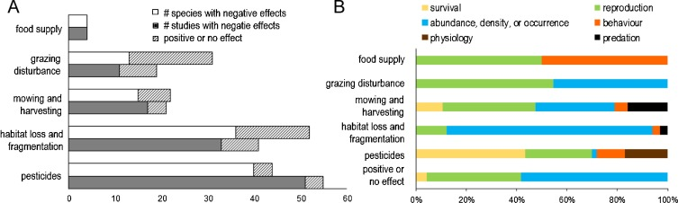

1. [Download : Download high-res image (347KB)](https://ars.els-cdn.com/content/image/1-s2.0-S016788091730525X-gr4_lrg.jpg)
2. [Download : Download full-size image](https://ars.els-cdn.com/content/image/1-s2.0-S016788091730525X-gr4.jpg)

Fig. 4. Summary of the number of published studies (n = 122) and number of species (n = 59) for each primary agricultural driver that reported either a significant negative, positive or no effect (p > 0.05) (a). Percentage of studies investigating the different effect parameters (survival, reproduction, abundance, behaviour, physiology, and predation) for each of the 5 identified drivers or reporting a positive or no effect (b).

While total amount of applied insecticides (not all pesticides) and cases of acute lethal poisoning in birds have declined in recent decades (Köhler and Triebskorn, 2013, Osteen and Fernandez-Cornejo, 2013), increasing frequency and area of use, widespread seed-coating applications, and toxicity to birds remain problematic. This is coupled with the ongoing degradation of grassland and wetland habitat for agricultural use (Bartzen et al., 2010), which suggests losses of suitable farmland habitat, small scale habitat features and landscape complexity remain significant for many bird species in decline. A recent meta-analysis concluded that biodiversity losses were more strongly related to pesticide use than agricultural land area, although the authors cautioned that pesticide use could be correlated with other causal factors that are a proxy for agricultural intensification (e.g. farm size, disturbance frequency or plant diversity) (Gibbs et al., 2009). Mineau and Whiteside (2013) found acute pesticide toxicity was the best predictor of grassland bird population declines. However, a re-analysis by Hill et al. (2014) determined that models for grassland bird declines that included habitat availability had 1.3–21.0 times more support than insecticide [acute toxicity](https://www.sciencedirect.com/topics/agricultural-and-biological-sciences/acute-toxicity) alone. Therefore, we conclude that both pesticide use and habitat loss appear to be major drivers of agriculturally-associated bird declines in North America, with their magnitude of influence differentially affecting species at multiple spatial scales.

## 6. Recommendations for farmland management

Given evidence reported here, management of intensive agricultural landscapes should focus on addressing the two most common drivers of farmland bird population declines – loss of habitat and pesticide use – while considering actions that are economically sustainable. Reversal of avian declines can occur through both restoration of native grassland as well as implementing beneficial farming practices (Askins et al., 2007). The US [Conservation Reserve Program](https://www.sciencedirect.com/topics/agricultural-and-biological-sciences/conservation-reserve-program) (CRP), which provides landowners with monetary incentives to convert highly erodible cropland into wildlife habitat, has positively influenced a variety of grassland birds across the continent (Reynolds, 2005, Blank, 2013, Haegen et al., 2015). Natural buffers in agricultural fields can also serve an important conservation role, with avian abundance, richness, and diversity all higher in fields with 10% of the area converted to strips of [perennial](https://www.sciencedirect.com/topics/agricultural-and-biological-sciences/perennials) native grass when compared to control fields (Schulte et al., 2016).

Therefore, we recommend re-establishment or preservation of field margins, grassland patches, and other uncultivated areas to develop a more complex and permanent vegetation structure. This would allow for higher plant and insect diversity, as well as more nesting and foraging habitat for farmland birds, and would likely have a minimal impact on farm revenue or operations. Well-maintained agricultural buffers and prairie strips can reduce runoff and increase abundance of [pollinators](https://www.sciencedirect.com/topics/earth-and-planetary-sciences/pollinator) and birds while enhancing soil and nutrient retention (Schulte et al., 2017); minimizing soil loss has been found to [increase crop yields](https://www.sciencedirect.com/topics/agricultural-and-biological-sciences/crop-yields-increase) (Pimentel et al., 1995). Fields with edge habitat composed of diverse plants support higher diversity and abundance of bird species (Kross et al., 2016, Wilson et al., 2017); in turn, areas with higher avian abundance have reported lower densities of [crop pests](https://www.sciencedirect.com/topics/earth-and-planetary-sciences/crop-pest) (e.g. [weevils](https://www.sciencedirect.com/topics/agricultural-and-biological-sciences/curculionidae), a common crop pest on alfalfa) (Kross et al., 2016). In California, predation rates on insect [pest species](https://www.sciencedirect.com/topics/earth-and-planetary-sciences/pest-species) by farmland birds were highest in cropped areas near [hedgerows](https://www.sciencedirect.com/topics/earth-and-planetary-sciences/hedgerow) and shrubby field margins (Garfinkel and Johnson, 2015). Planting [sunflower](https://www.sciencedirect.com/topics/agricultural-and-biological-sciences/helianthus-annuus) (*Helianthus annuus*) intercrops resulted in greater abundance and foraging activity of insectivorous birds over the cropped area than in control plots (Jones and Sieving, 2006). Targeted management to increase use of field margins and habitat complexity on agricultural areas can benefit both farmers and biodiversity; despite these benefits, as of 2009 only 22.2% of farms in the US were enrolled in conservation programs supporting buffer use (Claassen et al., 2014). Obstacles and knowledge gaps inhibiting greater adoption of these programs need to be addressed including determining what the ideal spatial configuration is, what type of vegetation is most advantageous for various geographic regions and farmland birds and the associated costs.

We also recommend practices that support principles of [integrated pest management](https://www.sciencedirect.com/topics/earth-and-planetary-sciences/integrated-pest-management) (IPM) and, when feasible, organic or low-input systems, which can result in higher richness and abundance of a variety of organisms, including many bird species, compared to conventional, non-organic farming (Freemark and Kirk, 2001, Beecher et al., 2002, Hole et al., 2005, Kirk and Lindsay, 2017). It is thought that avian species dependent upon crops for foraging would particularly benefit from organic agriculture, as differences in [nestling](https://www.sciencedirect.com/topics/agricultural-and-biological-sciences/nestlings) food biomass are more pronounced within [crop fields](https://www.sciencedirect.com/topics/agricultural-and-biological-sciences/field-crops) compared to other agricultural areas (Girard et al., 2012). While this type of agriculture could be highly beneficial from a biodiversity viewpoint, a recent meta-analysis found that organic farming still results in 19.2% (±3.7%) lower yields than conventional farming (Ponisio et al., 2014), which could produce concerns for global food security with more widespread use. With the recent widespread application of highly toxic pesticides routinely used as seed dressings, such as with [neonicotinoids](https://www.sciencedirect.com/topics/agricultural-and-biological-sciences/neonicotinoid) and many [fungicides](https://www.sciencedirect.com/topics/earth-and-planetary-sciences/fungicide), prophylactic use frequently leads to higher chemical inputs and farm costs than may be necessary. Fields using integrated pest management can lower costs to farmers and reduce pesticide risks as compared to prophylactic treatment, despite both methods producing an equivalent crop yield (Bueno et al., 2011). Concurrent monitoring of bird population responses and farm yields is a valid method to identify beneficial changes in farmland management that can be weighed against costs (e.g. Perlut et al., 2011, Evans et al., 2014).

## 7. Research needs

While farmland and grassland birds have been relatively under-studied, the number of papers published on the topic more than doubled from 1985 to 2010 (Koper and Nudds, 2011). However, studies of the lethal and sublethal effects of pesticides in field settings are needed, as are those to determine whether agriculturally-mediated declines in food supply indirectly affect farmland birds. There are still few field and captive investigations into the ecotoxicity of newer and widely used insecticides such as neonicotinoids (Mineau and Palmer, 2013, Eng et al., 2017).

Studies have demonstrated negative relationships between agricultural intensification and insect availability, and reduced food availability and lower survival and reproduction in birds, but rarely have these two topics been explicitly linked. Multi-trophic level linkages have been investigated for several species in Europe (see Brickle et al., 2000, Morris et al., 2005, Hart et al., 2006), but not in North America. There is also a need for research over larger spatial scales. Studies investigating the effectiveness of agri-environment schemes in promoting biodiversity in five European countries found mixed responses for different taxa and strongly recommend the incorporation of research over larger scales (Kleijn et al., 2006). Considerable variation in effects between regions exists, and so it is also imperative to determine the most effective conservation strategies that are locally adapted. Investigating the potential benefits of farmland improvement through [adaptive management](https://www.sciencedirect.com/topics/earth-and-planetary-sciences/adaptive-management) experiments would produce vital information, and help to determine biological and socioeconomic viability of different farm management schemes. Improved understanding of the mechanisms underpinning farmland bird declines and using this information to design multi-functional agricultural landscapes is urgently needed to stabilize or reverse the negative trends for many farmland-associated bird populations.

## Acknowledgements

We thank Chris Elphick and anonymous reviewers for comments on earlier drafts of this manuscript. This work was supported by Environment and Climate Change Canada, a Natural Sciences and Engineering Research Council of Canada (NSERC) Discovery Grant (RGPIN 04353-2014) to R. Clark, and NSERC Strategic Project (NSERC STPGP430138 − 12) and NSERC Discovery (RGPIN-2016-05436) Grants to C. Morrissey.

## Appendix A. Supplementary data

The following is Supplementary data to this article:[Download : Download Word document (78KB)](https://ars.els-cdn.com/content/image/1-s2.0-S016788091730525X-mmc1.docx)

## References

**Askins et al., 2007**

R.A. Askins, F. Chávez-Ramírez, B.C. Dale, C.A. Haas, J.R. Herkert, F.L. Knopf, P.D. Vickery

**Conservation of grassland birds in North America: understanding ecological processes in different regions**

Ornithol. Monogr., 64 (2007), pp. 1-46, 10.2307/40166905

Google Scholar

**Aspelin, 2003**

A.L. Aspelin

**Pesticide Usage in the United States: Trends During the 20th Century**

CIPM Technical Bulletin 105, Raleigh, North Carolina (2003)

[Google Scholar](https://scholar.google.com/scholar_lookup?title=Pesticide%20Usage%20in%20the%20United%20States%3A%20Trends%20During%20the%2020th%20Century&publication_year=2003&author=A.L.%20Aspelin)

**Attwood et al., 2008**

S.J. Attwood, M. Maron, A.P.N. House, C. Zammit

**Do arthropod assemblages display globally consistent responses to intensified agricultural land use and management?**

Global Ecol. Biogeogr., 17 (2008), pp. 585-599, 10.1111/j.1466-8238.2008.00399.x

[View Record in Scopus](https://www.scopus.com/inward/record.url?eid=2-s2.0-49449118866&partnerID=10&rel=R3.0.0)[Google Scholar](https://scholar.google.com/scholar?q=Do%20arthropod%20assemblages%20display%20globally%20consistent%20responses%20to%20intensified%20agricultural%20land%20use%20and%20management)

**Bartzen et al., 2010**

B.A. Bartzen, K.W. Dufour, R.G. Clark, F.D. Caswell

**Trends in agricultural impact and recovery of wetlands in prairie Canada**

Ecol. Appl., 20 (2010), pp. 525-538, 10.1890/08-1650.1

[View Record in Scopus](https://www.scopus.com/inward/record.url?eid=2-s2.0-77950175029&partnerID=10&rel=R3.0.0)Google Scholar

**Basili and Temple, 1999**

G.D. Basili, S.A. Temple

**Dickcissels and crop damage in Venezuela: defining the problem with ecological models**

Ecol. Appl., 9 (1999), pp. 732-739, 10.2307/2641158

[View Record in Scopus](https://www.scopus.com/inward/record.url?eid=2-s2.0-0033134715&partnerID=10&rel=R3.0.0)Google Scholar

**Basore et al., 1986**

N.S. Basore, L.B. Best, J.B. Wooley

**Bird nesting in Iowa no-tillage and tilled cropland**

J. Wildl. Manage., 50 (1986), pp. 19-28

[CrossRef](https://doi.org/10.2307/3801482)[View Record in Scopus](https://www.scopus.com/inward/record.url?eid=2-s2.0-0022859078&partnerID=10&rel=R3.0.0)[Google Scholar](https://scholar.google.com/scholar_lookup?title=Bird%20nesting%20in%20Iowa%20no-tillage%20and%20tilled%20cropland&publication_year=1986&author=N.S.%20Basore&author=L.B.%20Best&author=J.B.%20Wooley)

**Bayard and Elphick, 2010**

T.S. Bayard, C.S. Elphick

**How area sensitivity in birds is studied**

Conserv. Biol., 24 (2010), pp. 938-947, 10.1111/j.1523-1739.2010.01480.x

[View Record in Scopus](https://www.scopus.com/inward/record.url?eid=2-s2.0-77954750659&partnerID=10&rel=R3.0.0)[Google Scholar](https://scholar.google.com/scholar_lookup?title=How%20area%20sensitivity%20in%20birds%20is%20studied&publication_year=2010&author=T.S.%20Bayard&author=C.S.%20Elphick)

**Beecher et al., 2002**

N.A. Beecher, R.J. Johnson, R.M. Case, J.R. Brandle, L.J. Young

**Agroecology of birds in organic and nonorganic farmland**

Conserv. Biol., 16 (2002), pp. 1620-1631, 10.1046/j.1523-1739.2002.01228.x

[View Record in Scopus](https://www.scopus.com/inward/record.url?eid=2-s2.0-18744376850&partnerID=10&rel=R3.0.0)Google Scholar

**Benton et al., 2002**

T.G. Benton, D.M. Bryant, L. Cole, H.Q.P. Crick

**Linking agricultural practice to insect and bird populations: a historical study over three decades**

J. Appl. Ecol., 39 (2002), pp. 673-687, 10.1046/j.1365-2664.2002.00745.x

[View Record in Scopus](https://www.scopus.com/inward/record.url?eid=2-s2.0-0036054739&partnerID=10&rel=R3.0.0)Google Scholar

**Benton et al., 2003**

T.G. Benton, J.A. Vickery, J.D. Wilson

**Farmland biodiversity: is habitat heterogeneity the key?**

Trends Ecol. Evol., 18 (2003), pp. 182-188, 10.1016/S0169-5347(03)00011-9

[Article](https://www.sciencedirect.com/science/article/pii/S0169534703000119)[Download PDF](https://www.sciencedirect.com/science/article/pii/S0169534703000119/pdfft?md5=5cb310f0f163853c9e8bf7c32311bf84&pid=1-s2.0-S0169534703000119-main.pdf)[View Record in Scopus](https://www.scopus.com/inward/record.url?eid=2-s2.0-0037377128&partnerID=10&rel=R3.0.0)[Google Scholar](https://scholar.google.com/scholar?q=Farmland%20biodiversity:%20is%20habitat%20heterogeneity%20the%20key)

**Bishop et al., 2000**

C.A. Bishop, P. Ng, P. Mineau, J.S. Quinn, J. Struger

**Effects of pesticide spraying on chick growth, behavior, and parental care in tree swallows (*Tachycineta bicolor*) nesting in an apple orchard in Ontario, Canada**

Environ. Toxicol. Chem., 19 (2000), pp. 2286-2297, 10.1002/etc.5620190919

[View Record in Scopus](https://www.scopus.com/inward/record.url?eid=2-s2.0-0033635012&partnerID=10&rel=R3.0.0)Google Scholar

**Blank, 2013**

P.J. Blank

**Northern bobwhite response to Conservation Reserve Program habitat and landscape attributes**

J. Wildl. Manage., 77 (2013), pp. 68-74, 10.1002/jwmg.457

[View Record in Scopus](https://www.scopus.com/inward/record.url?eid=2-s2.0-84872070929&partnerID=10&rel=R3.0.0)[Google Scholar](https://scholar.google.com/scholar_lookup?title=Northern%20bobwhite%20response%20to%20Conservation%20Reserve%20Program%20habitat%20and%20landscape%20attributes&publication_year=2013&author=P.J.%20Blank)

**Bleho et al., 2014**

B.I. Bleho, N. Koper, C.S. Machtans

**Direct effects of cattle on grassland birds in Canada**

Conserv. Biol., 28 (2014), pp. 724-734, 10.1111/cobi.12259

[View Record in Scopus](https://www.scopus.com/inward/record.url?eid=2-s2.0-84900517705&partnerID=10&rel=R3.0.0)[Google Scholar](https://scholar.google.com/scholar_lookup?title=Direct%20effects%20of%20cattle%20on%20grassland%20birds%20in%20Canada&publication_year=2014&author=B.I.%20Bleho&author=N.%20Koper&author=C.S.%20Machtans)

**Boatman et al., 2004**

N.D. Boatman, N.W. Brickle, J.D. Hart, T.P. Milsom, A.J. Morris, A.W.A. Murray, K.A. Murray, P.A. Pobertson

**Evidence for the indirect effects of pesticides on farmland birds**

Ibis, 146 (2004), pp. 131-143, 10.1111/j.1474-919X.2004.00347.x

[View Record in Scopus](https://www.scopus.com/inward/record.url?eid=2-s2.0-5344247680&partnerID=10&rel=R3.0.0)Google Scholar

**Bollinger et al., 1990**

E. Bollinger, P.B. Bollinger, T.A. Gavin

**Effects of hay-cropping on eastern populations of the bobolink**

Wildl. Soc. Bull., 17 (1990), pp. 142-150

[View Record in Scopus](https://www.scopus.com/inward/record.url?eid=2-s2.0-0025593844&partnerID=10&rel=R3.0.0)Google Scholar

**Brennan and Kuvlesky, 2005**

L.A. Brennan, W.P. Kuvlesky

**North American grassland birds: an unfolding conservation crisis?**

J. Wildl Manage., 69 (2005), pp. 1-13, 10.2193/0022-541X(2005)069<0001:NAGBAU>2.0.CO2

[View Record in Scopus](https://www.scopus.com/inward/record.url?eid=2-s2.0-18044378390&partnerID=10&rel=R3.0.0)[Google Scholar](https://scholar.google.com/scholar?q=North%20American%20grassland%20birds:%20an%20unfolding%20conservation%20crisis)

**Brickle et al., 2000**

N.W. Brickle, D.G.C. Harper, N.J. Aebischer, S.H. Cockayne

**Effects of agricultural intensification on the breeding success of corn buntings *Miliaria calandra***

J. Appl. Ecol., 37 (2000), pp. 742-755, 10.1046/j.1365-2664.2000.00542.x

[View Record in Scopus](https://www.scopus.com/inward/record.url?eid=2-s2.0-0033676329&partnerID=10&rel=R3.0.0)Google Scholar

**Bueno et al., 2011**

A.D. Bueno, M.J. Batistela, R.C.O.D. Bueno, J.D. Franca-Neto, M.A.N. Nishikawa, A. Liberio

**Effects of integrated pest management, biological control and prophylactic use of insecticides on the management and sustainability of soybeans**

Crop Prot., 30 (2011), pp. 937-945, 10.1016/j.cropro.2011.02.021

[Article](https://www.sciencedirect.com/science/article/pii/S0261219411000640)[Download PDF](https://www.sciencedirect.com/science/article/pii/S0261219411000640/pdfft?md5=506894f3a6bd04b4c6c341cbcdec4720&pid=1-s2.0-S0261219411000640-main.pdf)[View Record in Scopus](https://www.scopus.com/inward/record.url?eid=2-s2.0-79955878926&partnerID=10&rel=R3.0.0)Google Scholar

**Calvert et al., 2013**

A.M. Calvert, C.A. Bishop, R.D. Elliot, E.A. Krebs, T.M. Kydd, C.S. Machtans, G.J. Robertson

**A synthesis of human-related avian mortality in Canada**

Avian Conserv. Ecol., 8 (2013), p. 11, 10.5751/ACE-00581-080211

[View Record in Scopus](https://www.scopus.com/inward/record.url?eid=2-s2.0-85012974517&partnerID=10&rel=R3.0.0)Google Scholar

**Canadian Wetland Inventory, 2008**

Canadian Wetland Inventory. 2008. Available from http://www.ducks.ca/cwi/(accessed December 2015).

[Google Scholar](https://scholar.google.com/scholar?q=Canadian%20Wetland%20Inventory.%202008.%20Available%20from%20http:www.ducks.cacwi.)

**Canadian Wildlife Service, 1991**

Canadian Wildlife Service

**The Federal Policy on Wetland Conservation**

(1991)

(Cat. No. CW66-116/1991E, ISBN 0-662-17940-X)

[Google Scholar](https://scholar.google.com/scholar_lookup?title=The%20Federal%20Policy%20on%20Wetland%20Conservation&publication_year=1991&author=Canadian%20Wildlife%20Service)

**Castrale, 1985**

J.S. Castrale

**Response of wildlife to various tillage conditions**

Trans. N. Am. Wildl. Nat. Resour. Conf., 50 (1985), pp. 142-156

[View Record in Scopus](https://www.scopus.com/inward/record.url?eid=2-s2.0-0000101911&partnerID=10&rel=R3.0.0)[Google Scholar](https://scholar.google.com/scholar_lookup?title=Response%20of%20wildlife%20to%20various%20tillage%20conditions&publication_year=1985&author=J.S.%20Castrale)

**Chamberlain et al., 2000**

D.E. Chamberlain, R.J. Fuller, R.G.H. Bunce, J.C. Duckworth, M. Shrubb

**Changes in the abundance of farmland birds in relation to the timing of agricultural intensification in England and Wales**

J. Appl. Ecol., 37 (2000), pp. 771-788, 10.1046/j.1365-2664.2000.00548.x

Google Scholar

**Claassen et al., 2014**

R. Claassen, J. Horowitz, E. Duquette, K. Ueda

**Additionality in U.S. Agricultural Conservation and Regulatory Offset Programs, ERR-170**

U.S. Department of Agriculture, Economic Research Service (2014)

(July 2014)

Google Scholar

**Dennis and Fry, 1992**

P. Dennis, G.L.A. Fry

**Field margins: can they enhance natural enemy population densities and general arthropod diversity on farmland**

Agric. Ecosyst. Environ., 40 (1992), pp. 95-115, 10.1016/0167-8809(92)90086-Q

[Article](https://www.sciencedirect.com/science/article/pii/B978044489390150010X)[Download PDF](https://www.sciencedirect.com/science/article/pii/B978044489390150010X/pdfft?md5=262bd11396ba82edb19d29050cf043eb&pid=3-s2.0-B978044489390150010X-main.pdf)Google Scholar

**Diemer and Nocera, 2016**

K.M. Diemer, J.J. Nocera

**Bobolink reproductive response to three hayfield management regimens in southern Ontario**

J. Nat. Conserv., 29 (2016), pp. 123-131, 10.1016/j.jnc.2015.12.007

[Article](https://www.sciencedirect.com/science/article/pii/S1617138115300406)[Download PDF](https://www.sciencedirect.com/science/article/pii/S1617138115300406/pdfft?md5=b3b1874af6d13cc1b7710f4dd367f1ec&pid=1-s2.0-S1617138115300406-main.pdf)[View Record in Scopus](https://www.scopus.com/inward/record.url?eid=2-s2.0-84954545878&partnerID=10&rel=R3.0.0)Google Scholar

**Donald et al., 2001**

P.F. Donald, R.E. Green, M.F. Heath

**Agricultural intensification and the collapse of Europe's farmland bird populations**

Proc. R. Soc. Lond. B Biol. Sci., 268 (2001), pp. 25-29, 10.1098/rspb.2000.1325

[Google Scholar](https://scholar.google.com/scholar?q=Agricultural%20intensification%20and%20the%20collapse%20of%20Europes%20farmland%20bird%20populations)

**Donald et al., 2006**

P.F. Donald, F.J. Sanderson, I.J. Burfield, F.P.J. van Bommel

**Further evidence of continent-wide impacts of agricultural intensification on European farmland birds, 1990–2000**

Agric. Ecosyst. Environ., 116 (2006), pp. 179-196, 10.1016/j.agee.2006.02.007

[Google Scholar](https://scholar.google.com/scholar?q=Further%20evidence%20of%20continent-wide%20impacts%20of%20agricultural%20intensification%20on%20European%20farmland%20birds,%2019902000)

**Downes et al., 2011**

C. Downes, P. Blancher, B. Collins

**Landbird Trends in Canada, 1968–2006. Canadian Biodiversity: Ecosystem Status and Trends 2010, Technical Thematic Report No. 12**

Canadian Councils of Resource Ministers, Ottawa, Ontario, Canada (2011)

[Google Scholar](https://scholar.google.com/scholar?q=Landbird%20Trends%20in%20Canada,%2019682006.%20Canadian%20Biodiversity:%20Ecosystem%20Status%20and%20Trends%202010,%20Technical%20Thematic%20Report%20No.%2012)

**Eng et al., 2017**

M.L. Eng, B.J. Stutchbury, C.A. Morrissey

**Imidacloprid and chlorpyrifos insecticides impair migratory ability in a seed-eating songbird**

Sci. Rep., 7 (2017), p. 15176, 10.1038/s41598-017-15446-x

[View Record in Scopus](https://www.scopus.com/inward/record.url?eid=2-s2.0-85033726134&partnerID=10&rel=R3.0.0)Google Scholar

**Evans et al., 2014**

K.O. Evans, L. Burger, S. Riffell, M.D. Smith

**Assessing multi-region avian benefits from strategically targeted agricultural buffers**

Conserv. Biol., 2 (2014), pp. 892-901, 10.1111/cobi.12311

[View Record in Scopus](https://www.scopus.com/inward/record.url?eid=2-s2.0-84904699193&partnerID=10&rel=R3.0.0)Google Scholar

**Fondell and Ball, 2004**

T.F. Fondell, I.J. Ball

**Density and success of bird nests relative to grazing on western Montana grasslands**

Biol. Conserv., 117 (2004), pp. 203-213, 10.1016/S0006-3207(03)00293-3

[Article](https://www.sciencedirect.com/science/article/pii/S0006320703002933)[Download PDF](https://www.sciencedirect.com/science/article/pii/S0006320703002933/pdfft?md5=48aba34079fca650b55b3e0613b5596c&pid=1-s2.0-S0006320703002933-main.pdf)[View Record in Scopus](https://www.scopus.com/inward/record.url?eid=2-s2.0-1242344032&partnerID=10&rel=R3.0.0)Google Scholar

**Freemark and Kirk, 2001**

K.E. Freemark, D.A. Kirk

**Birds on organic and conventional farms in Ontario: partitioning effects of habitat and practices on species composition and abundance**

Biol. Conserv., 101 (2001), pp. 337-350, 10.1016/S0006-3207(01)00079-9

[Article](https://www.sciencedirect.com/science/article/pii/S0006320701000799)[Download PDF](https://www.sciencedirect.com/science/article/pii/S0006320701000799/pdfft?md5=598d3604302b79d48a3bcdf87f856a55&pid=1-s2.0-S0006320701000799-main.pdf)[View Record in Scopus](https://www.scopus.com/inward/record.url?eid=2-s2.0-0034866196&partnerID=10&rel=R3.0.0)Google Scholar

**Friend and Franson, 1999**

M. Friend, J.C. Franson

**Field Manual of Wildlife Diseases – General Field Procedures and Diseases of Birds. Chapter 39: Organophosphates and Carbamates. In Information and Technology Report**

US Department of the Interior and US Geological Survey. (1999)

Google Scholar

**Fuller et al., 1995**

R.J. Fuller, R.D. Gregory, D.W. Gibbons, J.H. Marchant, J.D. Wilson, S.R. Baillie, N. Carter

**Population declines and range contractions among lowland farmland birds in Britain**

Conserv. Biol., 9 (1995), pp. 1425-1441, 10.1046/j.1523-1739.1995.09061425.x

[View Record in Scopus](https://www.scopus.com/inward/record.url?eid=2-s2.0-0028995699&partnerID=10&rel=R3.0.0)Google Scholar

**Gade, 2010**

D.W. Gade

**Shifting synanthropy of the crow in eastern North America**

Geogr. Rev., 100 (2010), pp. 152-175, 10.1111/j.1931-0846.2010.00019.x

[View Record in Scopus](https://www.scopus.com/inward/record.url?eid=2-s2.0-77952923297&partnerID=10&rel=R3.0.0)[Google Scholar](https://scholar.google.com/scholar_lookup?title=Shifting%20synanthropy%20of%20the%20crow%20in%20eastern%20North%20America&publication_year=2010&author=D.W.%20Gade)

**Galle et al., 2009**

A.M. Galle, G.M. Linz, H.J. Homan, W.J. Bleier

**Avian use of harvested crop fields in North Dakota during spring migration**

West. N. Am. Nat., 69 (2009), pp. 491-500, 10.3398/064.069.0409

[View Record in Scopus](https://www.scopus.com/inward/record.url?eid=2-s2.0-73649088656&partnerID=10&rel=R3.0.0)Google Scholar

**Garfinkel and Johnson, 2015**

M. Garfinkel, M. Johnson

**Pest-removal services provided by birds on small organic farms in northern California**

Agric. Ecosyst. Environ., 211 (2015), pp. 24-31, 10.1016/j.agee.2015.04.023

[Article](https://www.sciencedirect.com/science/article/pii/S0167880915001565)[Download PDF](https://www.sciencedirect.com/science/article/pii/S0167880915001565/pdfft?md5=a23089a97938f2e064a6ff11026a8a9f&pid=1-s2.0-S0167880915001565-main.pdf)[View Record in Scopus](https://www.scopus.com/inward/record.url?eid=2-s2.0-84930674029&partnerID=10&rel=R3.0.0)Google Scholar

**Gibbs et al., 2009**

K.E. Gibbs, R.L. Mackey, D.J. Currie

**Human land use, agriculture, pesticides and losses of imperiled species**

Divers. Distrib., 15 (2009), pp. 242-253, 10.1111/j.1472-4642.2008.00543.x

Google Scholar

**Girard et al., 2012**

J. Girard, A. Baril, P. Mineau, L. Fahrig

**Foraging habitat and diet of Song Sparrows (*Melospiza melodia*) nesting in farmland: a stable isotope approach**

Can. J. Zool., 90 (2012), pp. 1339-1350, 10.1139/z2012-103

[View Record in Scopus](https://www.scopus.com/inward/record.url?eid=2-s2.0-84868308613&partnerID=10&rel=R3.0.0)[Google Scholar](https://scholar.google.com/scholar?q=Foraging%20habitat%20and%20diet%20of%20Song%20Sparrows%20%20nesting%20in%20farmland:%20a%20stable%20isotope%20approach)

1

4

0

**Giuliano and Daves, 2002**

W.M. Giuliano, S.E. Daves

**Avian response to warm-season grass use in pasture and hayfield management**

Biol. Conserv., 106 (2002), pp. 1-9, 10.1016/S0006-3207(01)00126-4

[Article](https://www.sciencedirect.com/science/article/pii/S0006320701001264)[Download PDF](https://www.sciencedirect.com/science/article/pii/S0006320701001264/pdfft?md5=d9d4ee575fdea4eaae5d53a2aec54560&pid=1-s2.0-S0006320701001264-main.pdf)[View Record in Scopus](https://www.scopus.com/inward/record.url?eid=2-s2.0-0036256908&partnerID=10&rel=R3.0.0)[Google Scholar](https://scholar.google.com/scholar_lookup?title=Avian%20response%20to%20warm-season%20grass%20use%20in%20pasture%20and%20hayfield%20management&publication_year=2002&author=W.M.%20Giuliano&author=S.E.%20Daves)

54

1

38

0

**Goulson, 2014**

D. Goulson

**Pesticides linked to bird declines**

Nature, 511 (2014), pp. 295-296, 10.1038/nature13642

[View Record in Scopus](https://www.scopus.com/inward/record.url?eid=2-s2.0-84904413903&partnerID=10&rel=R3.0.0)[Google Scholar](https://scholar.google.com/scholar_lookup?title=Pesticides%20linked%20to%20bird%20declines&publication_year=2014&author=D.%20Goulson)

91

0

56

1

**Graber and Graber, 1963**

R.R. Graber, J.W. Graber

**A comparative study of bird populations in Illinois, 1906–1909 and 1956–1958**

Ill. Nat. Hist. Surv. Bull., 28 (1963), pp. 383-528

[CrossRef](https://doi.org/10.21900/j.inhs.v28.169)[View Record in Scopus](https://www.scopus.com/inward/record.url?eid=2-s2.0-0001288491&partnerID=10&rel=R3.0.0)[Google Scholar](https://scholar.google.com/scholar?q=A%20comparative%20study%20of%20bird%20populations%20in%20Illinois,%2019061909%20and%2019561958)

50

2

46

1

**Green et al., 2005**

R.E. Green, S.J. Cornell, J.P. Scharlemann, A. Balmford

**Farming and the fate of wild nature**

Science, 307 (2005), pp. 550-555, 10.1126/science.1106049

[View Record in Scopus](https://www.scopus.com/inward/record.url?eid=2-s2.0-12844280433&partnerID=10&rel=R3.0.0)[Google Scholar](https://scholar.google.com/scholar_lookup?title=Farming%20and%20the%20fate%20of%20wild%20nature&publication_year=2005&author=R.E.%20Green&author=S.J.%20Cornell&author=J.P.%20Scharlemann&author=A.%20Balmford)

1,477

8

1,260

3

**Greenberg et al., 2011**

R. Greenberg, W. Demarest, S.M. Matsuoka, C. Mettke-Hofmann, D. Evers, P.B. Hamel, J. Luscier, L.L. Powell, D. Shaw, M.L. Avery, K.A. Hobson, P.J. Blancher, D.K. Niven

**Understanding declines in rusty blackbirds**

J.V. Wells (Ed.), Boreal Birds of North America: a Hemispheric View of Their Conservation Links and Significance, University of California Press, Berkeley CA (2011), pp. 107-126

Google Scholar

**Gregory and Marchant, 1996**

R.D. Gregory, J.H. Marchant

**Population trends of jays, magpies, jackdaws and carrioncrows in the UK**

Bird Study, 43 (1996), pp. 28-37, 10.1080/00063659609460993

[View Record in Scopus](https://www.scopus.com/inward/record.url?eid=2-s2.0-0030446020&partnerID=10&rel=R3.0.0)Google Scholar

71

2

60

0

**Grue et al., 1982**

C.E. Grue, G.V.N. Powell, M.J. McChesney

**Care of nestlings by wild female starlings exposed to an organophosphate pesticide**

J. Appl. Ecol., 19 (1982), pp. 327-335

[CrossRef](https://doi.org/10.2307/2403470)[View Record in Scopus](https://www.scopus.com/inward/record.url?eid=2-s2.0-0020461547&partnerID=10&rel=R3.0.0)Google Scholar

73

3

39

1

**Haegen et al., 2015**

W. Haegen, M.A. Schroeder, W.Y. Chang, S.M. Knapp

**Avian abundance and reproductive success in the intermountain west: local-scale response to the conservation reserve program**

Wildl. Soc. Bull., 39 (2015), pp. 276-291, 10.1002/wsb.523

[View Record in Scopus](https://www.scopus.com/inward/record.url?eid=2-s2.0-84946055254&partnerID=10&rel=R3.0.0)Google Scholar

4

0

0

0

**Hallmann et al., 2014**

C.A. Hallmann, R.P. Foppen, C.A. van Turnhout, H. de Kroon, E. Jongejans

**Declines in insectivorous birds are associated with high neonicotinoid concentrations**

Nature, 511 (2014), pp. 341-343, 10.1038/nature13531

Google Scholar

601

11

412

3

**Haroune, 2015**

Lounès Haroune, *et al.*

**Liquid chromatography-tandem mass spectrometry determination for multiclass pesticides from insect samples by microwave-assisted solvent extraction followed by a salt-out effect and micro-dispersion purification**

Anal. Chim Acta, 891 (2015), pp. 160-170, 10.1016/j.aca.2015.07.031

[Article](https://www.sciencedirect.com/science/article/pii/S0003267015008843)[Download PDF](https://www.sciencedirect.com/science/article/pii/S0003267015008843/pdfft?md5=d14fc68ef402af6d525c15d791fed4b3&pid=1-s2.0-S0003267015008843-main.pdf)[View Record in Scopus](https://www.scopus.com/inward/record.url?eid=2-s2.0-84941876728&partnerID=10&rel=R3.0.0)Google Scholar

39

1

23

0

**Hart et al., 2006**

J.D. Hart, T.P. Milsom, G. Fisher, V. Wilkins, S.J. Moreby, A.W.A. Murray, P.A. Robertson

**The relationship between yellowhammer breeding performance, arthropod abundance and insecticide applications on arable farmland**

J. Appl. Ecol., 43 (2006), pp. 81-91, 10.1111/j.1365-2664.2005.01103.x

[View Record in Scopus](https://www.scopus.com/inward/record.url?eid=2-s2.0-33645106028&partnerID=10&rel=R3.0.0)Google Scholar

81

3

85

0

**Helzer and Jelinski, 1999**

C.J. Helzer, D.E. Jelinski

**The relative importance of patch area and perimeter-area ratio to grassland breeding birds**

Ecol. Appl., 9 (1999), pp. 1448-1458, 10.1890/1051-0761(1999)009[1448:TRIOPA]2.0.CO;2

[View Record in Scopus](https://www.scopus.com/inward/record.url?eid=2-s2.0-0032697652&partnerID=10&rel=R3.0.0)Google Scholar

0

0

0

0

**Herkert et al., 1996**

J.R. Herkert, D.W. Sample, R.E. Warner

**Management of Midwestern Grassland Landscapes for the Conservation of Migratory Birds**

U.S. Dept. of Agriculture, Forest Service, North Central Forest Experiment Station, St. Paul, MN (1996)

Google Scholar

**Herkert, 1997**

J.R. Herkert

**Bobolink *Dolichonyx oryzivorus* population decline in agricultural landscapes in the midwestern USA**

Biol. Conserv., 80 (1997), pp. 107-112, 10.1016/S0006-3207(96)00066-3

[Article](https://www.sciencedirect.com/science/article/pii/S0006320796000663)[Download PDF](https://www.sciencedirect.com/science/article/pii/S0006320796000663/pdf?md5=9518b896a44613dd982400a5fc91e6a0&pid=1-s2.0-S0006320796000663-main.pdf)[View Record in Scopus](https://www.scopus.com/inward/record.url?eid=2-s2.0-0031107138&partnerID=10&rel=R3.0.0)Google Scholar

54

3

38

0

**Herkert, 2003**

J.R. Herkert, *et al.*

**Effects of prairie fragmentation on the nest success of breeding birds in the midcontinental United States**

Conserv. Biol., 17 (2003), pp. 587-594, 10.1046/j.1523-1739.2003.01418.x

[View Record in Scopus](https://www.scopus.com/inward/record.url?eid=2-s2.0-0043241945&partnerID=10&rel=R3.0.0)Google Scholar

155

6

98

2

**Hill et al., 2014**

J.M. Hill, J.F. Egan, G.E. Stauffer, D.R. Diefenbach

**Habitat availability is a more plausible explanation than insecticide acute toxicity for US grassland bird species declines**

PLoS One (2014), p. e98064, 10.1371/journal.pone.0098064

[View Record in Scopus](https://www.scopus.com/inward/record.url?eid=2-s2.0-84901364536&partnerID=10&rel=R3.0.0)Google Scholar

37

2

28

0

**Hole et al., 2005**

D.G. Hole, A.J. Perkins, J.D. Wilson, I.H. Alexander, P.V. Grice, A.D. Evans

**Does organic farming benefit biodiversity?**

Biol. Conserv., 122 (2005), pp. 113-130, 10.1016/j.biocon.2004.07.018

[Article](https://www.sciencedirect.com/science/article/pii/S0006320704003246)[Download PDF](https://www.sciencedirect.com/science/article/pii/S0006320704003246/pdfft?md5=4b7727eba26db9f40a1fab799b9e28d0&pid=1-s2.0-S0006320704003246-main.pdf)[View Record in Scopus](https://www.scopus.com/inward/record.url?eid=2-s2.0-4644255313&partnerID=10&rel=R3.0.0)[Google Scholar](https://scholar.google.com/scholar?q=Does%20organic%20farming%20benefit%20biodiversity)

1,071

36

711

2

**Horn et al., 2005**

D.J. Horn, M.L. Phillips, R.R. Koford, W.R. Clark, M.A. Sovada, R.J. Greenwood

**Landscape composition, patch size, and distance to edges: interactions affecting duck reproductive success**

Ecol. Appl., 15 (2005), pp. 1367-1376, 10.1890/03-5254

[View Record in Scopus](https://www.scopus.com/inward/record.url?eid=2-s2.0-23044457787&partnerID=10&rel=R3.0.0)Google Scholar

43

8

71

1

**Hudson et al., 1984**

R.H. Hudson, R.K. Tucker, M.A. Haegele

**Handbook of Toxicity of Pesticides to Wildlife**

(2nd ed.), Resource Publication 153. U.S. Fish and Wildlife Service, Washington, DC (1984)

[Google Scholar](https://scholar.google.com/scholar_lookup?title=Handbook%20of%20Toxicity%20of%20Pesticides%20to%20Wildlife&publication_year=1984&author=R.H.%20Hudson&author=R.K.%20Tucker&author=M.A.%20Haegele)

**Jeschke et al., 2011**

P. Jeschke, R. Nauen, M. Schindler, A. Elbert

**Overview of the status and global strategy for neonicotinoids**

J. Agric. Food Chem., 59 (2011), pp. 2897-2908, 10.1021/jf101303g

[View Record in Scopus](https://www.scopus.com/inward/record.url?eid=2-s2.0-79953855255&partnerID=10&rel=R3.0.0)Google Scholar

1,118

5

878

2

**Jobin et al., 2001**

B. Jobin, L. Choinière, L. Bélanger

**Bird use of three types of field margins in relation to intensive agriculture in Québec, Canada**

Agric. Ecosyst. Environ., 84 (2001), pp. 131-143, 10.1016/S0167-8809(00)00206-1

[Article](https://www.sciencedirect.com/science/article/pii/S0167880900002061)[Download PDF](https://www.sciencedirect.com/science/article/pii/S0167880900002061/pdfft?md5=b852d31dfae5d7255889b0e78941c46f&pid=1-s2.0-S0167880900002061-main.pdf)[View Record in Scopus](https://www.scopus.com/inward/record.url?eid=2-s2.0-0035117353&partnerID=10&rel=R3.0.0)Google Scholar

63

1

41

0

**Jones and Sieving, 2006**

G.A. Jones, K.E. Sieving

**Intercropping sunflower in organic vegetables to augment bird predators of arthropods**

Agric. Ecosyst. Environ., 117 (2006), pp. 171-177, 10.1016/j.agee.2006.03.026

[Article](https://www.sciencedirect.com/science/article/pii/S0167880906001290)[Download PDF](https://www.sciencedirect.com/science/article/pii/S0167880906001290/pdfft?md5=38e1f2a5c06461098e654908de250e23&pid=1-s2.0-S0167880906001290-main.pdf)[View Record in Scopus](https://www.scopus.com/inward/record.url?eid=2-s2.0-33748946395&partnerID=10&rel=R3.0.0)Google Scholar

48

0

29

0

**Köhler and Triebskorn, 2013**

H.R. Köhler, R. Triebskorn

**Wildlife ecotoxicology of pesticides: can we track effects to the population level and beyond?**

Science, 341 (2013), pp. 759-765, 10.1126/science.1237591

[Google Scholar](https://scholar.google.com/scholar?q=Wildlife%20ecotoxicology%20of%20pesticides:%20can%20we%20track%20effects%20to%20the%20population%20level%20and%20beyond)

523

6

298

1

**Kirk and Lindsay, 2017**

D.A. Kirk, K.E.F. Lindsay

**Subtle differences in birds detected between organic and nonorganic farms in Saskatchewan Prairie Parklands by farm pair and bird functional group**

Agric. Ecosyst. Environ., 246 (2017), pp. 184-201, 10.1016/j.agee.2017.04.009

[Article](https://www.sciencedirect.com/science/article/pii/S0167880917301652)[Download PDF](https://www.sciencedirect.com/science/article/pii/S0167880917301652/pdfft?md5=b3a9981d390eb7858241faafa2db86f2&pid=1-s2.0-S0167880917301652-main.pdf)[View Record in Scopus](https://www.scopus.com/inward/record.url?eid=2-s2.0-85020755253&partnerID=10&rel=R3.0.0)Google Scholar

10

1

6

0

**Kirk et al., 2011**

D.A. Kirk, K.F. Lindsay, R.W. Brook

**Risk of agricultural practices and habitat changes to farmland birds**

Avian Conserv. Ecol., 6 (2011), p. 5, 10.5751/ACE-00446-060105

[View Record in Scopus](https://www.scopus.com/inward/record.url?eid=2-s2.0-78650877090&partnerID=10&rel=R3.0.0)Google Scholar

14

1

12

0

**Kleijn et al., 2006**

D. Kleijn, R.A. Baquero, Y. Clough, M. Diaz, J. De Esteban, F. Fernandez, D. Gabriel, F. Herzog, A. Holzschuh, R. Johl, E. Knop, A. Kruess, E.J.P. Marshall, I. Steffan-Dewenter, T. Tscharntke, J. Verhulst, T.M. West, J.L. Yela

**Mixed biodiversity benefits of agrienvironment schemes in five European countries**

Ecol. Lett., 9 (2006), pp. 243-254, 10.1111/j.1461-0248.2005.00869.x

Google Scholar

781

8

557

6

**Klute et al., 1997**

D.S. Klute, R.J. Robel, K.E. Kemp

**Will conversion of Conservation Reserve Program (CRP) lands to pasture be detrimental for grassland birds in Kansas?**

Am Midl. Nat., 137 (1997), pp. 206-212, 10.2307/2426840

[View Record in Scopus](https://www.scopus.com/inward/record.url?eid=2-s2.0-0030995471&partnerID=10&rel=R3.0.0)[Google Scholar](https://scholar.google.com/scholar?q=Will%20conversion%20of%20Conservation%20Reserve%20Program%20%20lands%20to%20pasture%20be%20detrimental%20for%20grassland%20birds%20in%20Kansas)

23

0

24

0

**Koper and Nudds, 2011**

N. Koper, T.D. Nudds

**Progress in research on grassland bird conservation and ecology**

Avian Conserv. Ecol., 6 (2011), p. 6, 10.5751/ACE-00461-060106

[Google Scholar](https://scholar.google.com/scholar_lookup?title=Progress%20in%20research%20on%20grassland%20bird%20conservation%20and%20ecology&publication_year=2011&author=N.%20Koper&author=T.D.%20Nudds)

3

0

3

0

**Kross et al., 2016**

S.M. Kross, T.R. Kelsey, C.J. McColl, J.M. Townsend

**Field-scale habitat complexity enhances avian conservation and avian-mediated pest-control services in an intensive agricultural crop**

Agric. Ecosyst. Environ., 225 (2016), pp. 140-149, 10.1016/j.agee.2016.03.043

[Article](https://www.sciencedirect.com/science/article/pii/S016788091630189X)[Download PDF](https://www.sciencedirect.com/science/article/pii/S016788091630189X/pdfft?md5=2d8d3506a9e1702ece82ec6ee21ef70c&pid=1-s2.0-S016788091630189X-main.pdf)[View Record in Scopus](https://www.scopus.com/inward/record.url?eid=2-s2.0-84964380493&partnerID=10&rel=R3.0.0)Google Scholar

32

3

29

0

**Kumar, 1996**

A. Kumar

**Seasonal variations in the calorific contents of certain predatory insects in a village fish pond of Santhal Parganas (Bihar)**

J. Environ. Biol., 17 (1996), pp. 59-62

[View Record in Scopus](https://www.scopus.com/inward/record.url?eid=2-s2.0-0029947373&partnerID=10&rel=R3.0.0)[Google Scholar](https://scholar.google.com/scholar?q=Seasonal%20variations%20in%20the%20calorific%20contents%20of%20certain%20predatory%20insects%20in%20a%20village%20fish%20pond%20of%20Santhal%20Parganas)

**Lacher et al., 2010**

T.E. Lacher, J.W. Bickham, C. Gascon, R.E. Green, R.D. Moore, M. Mora

**Impacts of contaminants and pesticides on biodiversity and ecosystem structure and function**

R.J. Kendall, T.E. Lacher, G.C. Cobb, S. Boyd Cox (Eds.), Wildlife Toxicology: Emerging Contaminant and Biodiversity Issues, CRC Press, Boca Raton FL (2010), pp. 112-145

Google Scholar

**Lindsay et al., 2013**

K.E. Lindsay, D.A. Kirk, T.M. Bergin, L.B. Best, J.C. Sifneos, J. Smith

**Farmland heterogeneity benefits birds in American mid-west watersheds**

Am. Midl. Nat., 170 (2013), pp. 121-143, 10.1674/0003-0031-170.1.121

[View Record in Scopus](https://www.scopus.com/inward/record.url?eid=2-s2.0-84880222264&partnerID=10&rel=R3.0.0)Google Scholar

21

2

9

1

**Martin and Gavin, 1995**

S.G. Martin, T.A. Gavin

**Bobolink (*Dolichonyx oryzivorus*) No. 176**

A. Poole, F. Gill (Eds.), The Birds of North America, The Academy of Natural Sciences/The American Ornithologists’ Union, Philadelphia/Washington DC (1995)

[Google Scholar](https://scholar.google.com/scholar?q=Bobolink%20%20No.%20176)

**Mayne et al., 2005**

G.J. Mayne, C.A. Bishop, P.A. Martin, H.J. Boermans, B. Hunter

**Thyroid function in nestling tree swallows and eastern bluebirds exposed to non-persistent pesticides and p, p′-DDE in apple orchards of southern Ontario, Canada**

Ecotoxicology, 14 (2005), pp. 381-396, 10.1007/s10646-004-6372-9

[View Record in Scopus](https://www.scopus.com/inward/record.url?eid=2-s2.0-17744394563&partnerID=10&rel=R3.0.0)Google Scholar

25

0

13

0

**McLaughlin and Mineau, 1995**

A. McLaughlin, P. Mineau

**The impact of agricultural practices on biodiversity**

Agric. Ecosyst. Environ., 55 (1995), pp. 201-212, 10.1016/0167-8809(95)00609-V

[Article](https://www.sciencedirect.com/science/article/pii/016788099500609V)[Download PDF](https://www.sciencedirect.com/science/article/pii/016788099500609V/pdf?md5=3e27210f55310217f89494c1383b9069&pid=1-s2.0-016788099500609V-main.pdf)[View Record in Scopus](https://www.scopus.com/inward/record.url?eid=2-s2.0-0028994583&partnerID=10&rel=R3.0.0)[Google Scholar](https://scholar.google.com/scholar_lookup?title=The%20impact%20of%20agricultural%20practices%20on%20biodiversity&publication_year=1995&author=A.%20McLaughlin&author=P.%20Mineau)

467

2

231

1

**Michel et al., 2016**

N.L. Michel, A.C. Smith, R.G. Clark, C.A. Morrissey, K.A. Hobson

**Differences in spatial synchrony and interspecific concordance inform guild-level population trends for aerial insectivorous birds**

Ecography, 39 (2016), pp. 774-786, 10.1111/ecog.01798

[View Record in Scopus](https://www.scopus.com/inward/record.url?eid=2-s2.0-84949009172&partnerID=10&rel=R3.0.0)Google Scholar

74

1

78

0

**Mineau and McLaughlin, 1996**

P. Mineau, A. McLaughlin

**Conservation of biodiversity within Canadian agricultural landscapes: preserving habitat for wildlife**

J. Agric. Environ. Ethics, 9 (1996), pp. 93-113, 10.1007/BF03055296

[View Record in Scopus](https://www.scopus.com/inward/record.url?eid=2-s2.0-0030428182&partnerID=10&rel=R3.0.0)Google Scholar

44

0

21

0

**Mineau and Palmer, 2013**

P. Mineau, C. Palmer

**The Impact of the Nation's Most Widely Used Insecticides on Birds**

American Bird Conservancy, USA (2013)

[Google Scholar](https://scholar.google.com/scholar?q=The%20Impact%20of%20the%20Nations%20Most%20Widely%20Used%20Insecticides%20on%20Birds)

**Mineau and Whiteside, 2013**

P. Mineau, M. Whiteside

**Pesticide acute toxicity is a better correlate of US grassland bird declines than agricultural intensification**

PLoS One (2013), p. e57457, 10.1371/journal.pone.0057457

[View Record in Scopus](https://www.scopus.com/inward/record.url?eid=2-s2.0-84874261527&partnerID=10&rel=R3.0.0)Google Scholar

146

3

133

3

**Mineau et al., 1999**

P. Mineau, M.R. Fletcher, L.C. Glaser, N.J. Thomas, C. Brassard, L.K. Wilson, J.E. Elliott, L.A. Lyon, C.J. Henny, T. Bollinger, S.L. Porter

**Poisoning of raptors with organoposphorus and carbamate pesticides with emphasis on Canada, US and UK**

J. Raptor. Res., 33 (1999), pp. 1-37

[View Record in Scopus](https://www.scopus.com/inward/record.url?eid=2-s2.0-0032871722&partnerID=10&rel=R3.0.0)Google Scholar

**Mineau et al., 2005**

P. Mineau, C.M. Downes, D.A. Kirk, E. Bayne, M. Csizy

**Patterns of bird species abundance in relation to granular insecticide use in the Canadian prairies**

Ecoscience, 12 (2005), pp. 267-278, 10.2980/i1195-6860-12-2-267.1

[View Record in Scopus](https://www.scopus.com/inward/record.url?eid=2-s2.0-21444449571&partnerID=10&rel=R3.0.0)Google Scholar

37

0

21

0

**Mineau, 1993**

P. Mineau

**The Hazard of Carbofuran to Birds and Other Vertebrate Wildlife. Canadian Wildlife Service Technical Report Series No. 177**

Environment Canada, Ottawa, Ontario (1993)

Google Scholar

**Mineau, 2004**

P. Mineau

**Birds and pesticides: are pesticide regulatory decisions consistent with the protection afforded migratory bird species under the Migratory Bird Treaty Act?**

Wm. & Mary Envtl. L. & Pol'y Rev., 28 (2004), pp. 313-338

[View Record in Scopus](https://www.scopus.com/inward/record.url?eid=2-s2.0-21444439328&partnerID=10&rel=R3.0.0)Google Scholar

**Mineau, 2005**

P. Mineau

**Direct losses of birds to pesticides –Beginnings of a quantification**

C.J. Ralph, T.D. Rich (Eds.), Bird Conservation Implementation and Integration in the Americas: Proceedings of the Third International Partners in Flight Conference 2002, U.S.D.A. Forest Service, Albany, CA (2005), pp. 1065-1070

[View Record in Scopus](https://www.scopus.com/inward/record.url?eid=2-s2.0-77953782385&partnerID=10&rel=R3.0.0)[Google Scholar](https://scholar.google.com/scholar?q=Direct%20losses%20of%20birds%20to%20pesticides%20Beginnings%20of%20a%20quantification)

**Morandin et al., 2014**

L.A. Morandin, R.F. Long, C. Kremen

**Hedgerows enhance beneficial insects on adjacent tomato fields in an intensive agricultural landscape**

Agric. Ecosyst. Environ., 189 (2014), pp. 164-170, 10.1016/j.agee.2014.03.030

[Article](https://www.sciencedirect.com/science/article/pii/S0167880914001662)[Download PDF](https://www.sciencedirect.com/science/article/pii/S0167880914001662/pdfft?md5=a627959a0cdf2d5a6687bd697a913448&pid=1-s2.0-S0167880914001662-main.pdf)[View Record in Scopus](https://www.scopus.com/inward/record.url?eid=2-s2.0-84925961827&partnerID=10&rel=R3.0.0)Google Scholar

94

2

55

0

**Morris et al., 2005**

A.J. Morris, J.D. Wilson, M.J. Whittingham, R.B. Bradbury

**Indirect effects of pesticides on breeding yellowhammer (*Emberiza citrinella*)**

Agric. Ecosyst. Environ., 106 (2005), pp. 1-16, 10.1016/j.agee.2004.07.016

[Article](https://www.sciencedirect.com/science/article/pii/S0167880904002191)[Download PDF](https://www.sciencedirect.com/science/article/pii/S0167880904002191/pdfft?md5=903a184d6e7d15da60b745baa8571401&pid=1-s2.0-S0167880904002191-main.pdf)[View Record in Scopus](https://www.scopus.com/inward/record.url?eid=2-s2.0-13744260487&partnerID=10&rel=R3.0.0)[Google Scholar](https://scholar.google.com/scholar?q=Indirect%20effects%20of%20pesticides%20on%20breeding%20yellowhammer)

70

3

65

0

**Murphy, 2003**

M.T. Murphy

**Avian population trends within the evolving agricultural landscape of Eastern and Central United States**

Auk, 120 (2003), pp. 20-34, 10.2307/4090137

[View Record in Scopus](https://www.scopus.com/inward/record.url?eid=2-s2.0-0037227132&partnerID=10&rel=R3.0.0)Google Scholar

37

0

40

2

**Nack and Ribic, 2005**

J.L. Nack, C.A. Ribic

**Apparent predation by cattle at grassland bird nests**

Wilson Bull., 117 (2005), pp. 56-62, 10.1676/04-056

[View Record in Scopus](https://www.scopus.com/inward/record.url?eid=2-s2.0-17844387401&partnerID=10&rel=R3.0.0)[Google Scholar](https://scholar.google.com/scholar_lookup?title=Apparent%20predation%20by%20cattle%20at%20grassland%20bird%20nests&publication_year=2005&author=J.L.%20Nack&author=C.A.%20Ribic)

27

1

15

0

**Nebel et al., 2010**

S. Nebel, A. Mills, J. McCracken, P. Taylor

**Declines of aerial insectivores in North America follow a geographic gradient**

Avian Conserv. Ecol., 5 (2010), p. 1, 10.5751/ACE-00391-050201

[View Record in Scopus](https://www.scopus.com/inward/record.url?eid=2-s2.0-85086819151&partnerID=10&rel=R3.0.0)Google Scholar

183

8

211

3

**Newton, 2004**

I. Newton

**The recent declines of farmland bird populations in Britain: an appraisal of causal factors and conservation actions**

Ibis, 146 (2004), pp. 579-600, 10.1111/j.1474-919X.2004.00375.x

[View Record in Scopus](https://www.scopus.com/inward/record.url?eid=2-s2.0-5344243795&partnerID=10&rel=R3.0.0)Google Scholar

532

6

461

3

**Nocera et al., 2005**

J.J. Nocera, G.J. Parsons, G.R. Milton, A.H. Fredeen

**Compatibility of delayed cutting regime with bird breeding and hay nutritional quality**

Agric. Ecosyst. Environ., 107 (2005), pp. 245-253, 10.1016/j.agee.2004.11.001

[Article](https://www.sciencedirect.com/science/article/pii/S0167880904003512)[Download PDF](https://www.sciencedirect.com/science/article/pii/S0167880904003512/pdfft?md5=e40c152249c8ba7fc228918806ab0cba&pid=1-s2.0-S0167880904003512-main.pdf)[View Record in Scopus](https://www.scopus.com/inward/record.url?eid=2-s2.0-16344385994&partnerID=10&rel=R3.0.0)Google Scholar

37

0

35

0

**Nocera et al., 2012**

J.J. Nocera, J.M. Blais, D.V. Beresford, L.K. Finity, C. Grooms, L.E. Kimpe, K. Kyser, N. Michelutti, M.W. Reudink, J.P. Smol

**Historical pesticide applications coincided with an altered diet of aerially foraging insectivorous chimney swifts**

Proc. R. Soc. London B Biol. Sci., 279 (2012), pp. 3114-3120, 10.1098/rspb.2012.0445

[View Record in Scopus](https://www.scopus.com/inward/record.url?eid=2-s2.0-84863094028&partnerID=10&rel=R3.0.0)Google Scholar

58

4

61

0

**O'Connor and Shrubb, 1986**

R.J. O'Connor, M. Shrubb

**Farming and Birds**

Cambridge University Press, Cambridge, UK (1986)

[Google Scholar](https://scholar.google.com/scholar_lookup?title=Farming%20and%20Birds&publication_year=1986&author=R.J.%20O%27Connor&author=M.%20Shrubb)

**Osteen and Fernandez-Cornejo, 2013**

C.D. Osteen, J. Fernandez-Cornejo

**Economic and policy issues of U.S. agricultural pesticide use trends**

Pest Manag. Sci., 69 (2013), pp. 1001-1025, 10.1002/ps.3529

[View Record in Scopus](https://www.scopus.com/inward/record.url?eid=2-s2.0-84881021879&partnerID=10&rel=R3.0.0)[Google Scholar](https://scholar.google.com/scholar_lookup?title=Economic%20and%20policy%20issues%20of%20U.S.%20agricultural%20pesticide%20use%20trends&publication_year=2013&author=C.D.%20Osteen&author=J.%20Fernandez-Cornejo)

101

2

87

1

**Paquette et al., 2013**

S. Rioux Paquette, D. Garant, F. Pelletier, M. Bélisle

**Seasonal patterns in tree swallow prey (Diptera) abundance are affected by agricultural intensification**

Ecol. Appl., 23 (2013), pp. 122-133, 10.1890/12-0068.1

[Google Scholar](https://scholar.google.com/scholar?q=Seasonal%20patterns%20in%20tree%20swallow%20prey%20%20abundance%20are%20affected%20by%20agricultural%20intensification)

55

5

57

0

**Perlut et al., 2006**

N.G. Perlut, A.M. Strong, T.M. Donovan, N.J. Buckley

**Grassland songbirds in a dynamic management landscape: behavioral responses and management strategies**

Ecol. Appl., 16 (2006), pp. 2235-2247, 10.1890/1051-0761(2006)016[2235:GSIADM]2.0.CO;2

[View Record in Scopus](https://www.scopus.com/inward/record.url?eid=2-s2.0-33845478793&partnerID=10&rel=R3.0.0)Google Scholar

0

0

0

0

**Perlut et al., 2011**

N.G. Perlut, A.M. Strong, T.J. Alexander

**A model for integrating wildlife science and agri-environmental policy in the conservation of declining species**

J. Wildl. Manage., 75 (2011), pp. 1657-1663, 10.1002/jwmg.199

[View Record in Scopus](https://www.scopus.com/inward/record.url?eid=2-s2.0-80051901078&partnerID=10&rel=R3.0.0)Google Scholar

29

0

28

1

**Perritt and Best, 1989**

J.E. Perritt, L.M. Best

**Effects of weather on the breeding ecology of Vesper Sparrows in Iowa crop fields**

Am. Midl. Nat., 121 (1989), pp. 355-360, 10.2307/2426040

[View Record in Scopus](https://www.scopus.com/inward/record.url?eid=2-s2.0-0024943936&partnerID=10&rel=R3.0.0)Google Scholar

3

0

5

0

**Pimentel et al., 1992**

D. Pimentel, H. Acquay, M. Biltonen, P. Rice, M. Silva, J. Nelson, V. Lipner, S. Giordano, A. Horowitz, M. D'amore

**Environmental and economic costs of pesticide use**

Bioscience, 42 (1992), pp. 750-760, 10.2307/1311994

Google Scholar

512

2

348

0

**Pimentel et al., 1995**

D. Pimentel, C. Harvey, P. Resosudarmo, K. Sinclair, D. Kurz, M. McNair, S. Crist, L. Shpritz, L. Fitton, R. Saffouri, R. Blair

**Environmental and economic costs of soil erosion and conservation benefit**

Science, 267 (1995), pp. 1117-1123, 10.1126/science.267.5201.1117

[View Record in Scopus](https://www.scopus.com/inward/record.url?eid=2-s2.0-0029105996&partnerID=10&rel=R3.0.0)Google Scholar

1,843

8

1,111

2

**Pimentel, 2005**

D. Pimentel

**Environmental and economic costs of the application of pesticides primarily in the United States**

Environ. Dev. Sustain., 7 (2005), pp. 229-252, 10.1007/s10668-005-7314-2

Google Scholar

611

2

401

0

**Ponisio et al., 2014**

L.C. Ponisio, L.K. M'Gonigle, K.C. Mace, J. Palomino, P. de Valpine, C. Kremen

**Diversification practices reduce organic to conventional yield gap**

Proc. R. Soc. London B Biol. Sci., 282 (2014), p. 20141396, 10.1098/rspb.2014.1396

Google Scholar

435

13

335

5

**Potts, 1986**

G.R. Potts

**The Partridge: Pesticides, Predation and Conservation**

Collins, London, UK (1986)

[Google Scholar](https://scholar.google.com/scholar_lookup?title=The%20Partridge%3A%20Pesticides%2C%20Predation%20and%20Conservation&publication_year=1986&author=G.R.%20Potts)

**Renfrew and Saavedra, 2007**

R.B. Renfrew, A.M. Saavedra

**Ecology and conservation of Bobolinks (*Dolichonyx oryzivorus*) in rice production regions of Bolivia**

Ornitol. Neotrop., 18 (2007), pp. 61-73

[View Record in Scopus](https://www.scopus.com/inward/record.url?eid=2-s2.0-34247252449&partnerID=10&rel=R3.0.0)[Google Scholar](https://scholar.google.com/scholar?q=Ecology%20and%20conservation%20of%20Bobolinks%20%20in%20rice%20production%20regions%20of%20Bolivia)

**Reynolds, 2005**

R.E. Reynolds

**The conservation reserve program and duck production in the United States’ prairie pothole region**

A.W. Allen, M.W. Vandever (Eds.), The Conservation Reserve Program?planting for the Future: Proceedings of a National Conference. U.S. Geological Survey, Biological Resources Discipline, Scientific Investigations Report 2005–5145 (2005), pp. 144-148

[View Record in Scopus](https://www.scopus.com/inward/record.url?eid=2-s2.0-85086153105&partnerID=10&rel=R3.0.0)[Google Scholar](https://scholar.google.com/scholar?q=The%20conservation%20reserve%20program%20and%20duck%20production%20in%20the%20United%20States%20prairie%20pothole%20region)

**Robertson et al., 1998**

G.J. Robertson, F. Cooke, R.I. Goudie, W.S. Boyd

**Moult speed predicts pairing success in male harlequin ducks**

Anim. Behav., 55 (1998), pp. 1677-1684, 10.1006/anbe.1997.0724

[Article](https://www.sciencedirect.com/science/article/pii/S0003347297907247)[Download PDF](https://www.sciencedirect.com/science/article/pii/S0003347297907247/pdf?md5=7ff514b29a73351588a1be361595d2c5&pid=1-s2.0-S0003347297907247-main.pdf)[View Record in Scopus](https://www.scopus.com/inward/record.url?eid=2-s2.0-0032103571&partnerID=10&rel=R3.0.0)Google Scholar

28

0

7

0

**Rodenhouse et al., 1995**

N.L. Rodenhouse, L.B. Best, R.J. O'Connor, E.K. Bollinger

**Effects of agricultural practices and farmland structures**

T.E. Martin, D.M. Finch (Eds.), Ecology and Management of Neotropical Migratory Birds: A Synthesis and Review of Critical Issues, Oxford University Press, New York (1995), pp. 269-293

Google Scholar

**Rodgers and Wooley, 1983**

R.D. Rodgers, J.B. Wooley

**Conservation tillage impacts on wildlife**

J. Soil Water Conserv., 38 (1983), pp. 212-213

[View Record in Scopus](https://www.scopus.com/inward/record.url?eid=2-s2.0-0021088636&partnerID=10&rel=R3.0.0)[Google Scholar](https://scholar.google.com/scholar_lookup?title=Conservation%20tillage%20impacts%20on%20wildlife&publication_year=1983&author=R.D.%20Rodgers&author=J.B.%20Wooley)

**Samson and Knopf, 1994**

F. Samson, F. Knopf

**Prairie conservation in north america**

Bioscience, 44 (1994), pp. 418-421, 10.2307/1312365

[Google Scholar](https://scholar.google.com/scholar_lookup?title=Prairie%20conservation%20in%20north%20america&publication_year=1994&author=F.%20Samson&author=F.%20Knopf)

967

2

697

0

**Samson et al., 2004**

F.B. Samson, F.L. Knopf, W. Ostlie

**Great plains ecosystems: past, present, and future**

Wildl. Soc. Bull., 32 (2004), pp. 6-15, 10.2193/0091-7648(2004)32[6:GPEPPA]2.0.CO;2

[View Record in Scopus](https://www.scopus.com/inward/record.url?eid=2-s2.0-2142758352&partnerID=10&rel=R3.0.0)[Google Scholar](https://scholar.google.com/scholar_lookup?title=Great%20plains%20ecosystems%3A%20past%2C%20present%2C%20and%20future&publication_year=2004&author=F.B.%20Samson&author=F.L.%20Knopf&author=W.%20Ostlie)

0

0

0

0

**Sauer et al., 2014**

J.R. Sauer, J.E. Hines, J.E. Fallon, K.L. Pardieck, Jr D.J. Ziolkowski, W.A. Link

**The North American Breeding Bird Survey, Results and Analysis 1966–2013 Version 01 30.2015**

USGS Patuxent Wildlife Research Center, Laurel, MD (2014)

[Google Scholar](https://scholar.google.com/scholar?q=The%20North%20American%20Breeding%20Bird%20Survey,%20Results%20and%20Analysis%2019662013%20Version%2001%2030.2015)

**Schertz, 1988**

D. Schertz

**Conservation tillage: an analysis of acreage projections in the United States**

J. Soil Water Conserv., 43 (1988), pp. 256-258

[View Record in Scopus](https://www.scopus.com/inward/record.url?eid=2-s2.0-0024156113&partnerID=10&rel=R3.0.0)[Google Scholar](https://scholar.google.com/scholar_lookup?title=Conservation%20tillage%3A%20an%20analysis%20of%20acreage%20projections%20in%20the%20United%20States&publication_year=1988&author=D.%20Schertz)

**Schifferli et al., 2014**

L. Schifferli, M.U. Grüebler, H.A.J. Meijer, G.H. Visser, B. Naef-Daenzer

**Barn swallow *Hirundo rustica* parents work harder when foraging conditions are good**

Ibis, 156 (2014), pp. 777-787, 10.1111/ibi.12186

[View Record in Scopus](https://www.scopus.com/inward/record.url?eid=2-s2.0-84927577668&partnerID=10&rel=R3.0.0)Google Scholar

19

2

19

0

**Schulte et al., 2016**

L.A. Schulte, A.L. MacDonald, J.B. Niemi, M.J. Helmers

**Prairie strips as a mechanism to promote land sharing by birds in industrial agricultural landscapes**

Agric. Ecosyst. Environ., 220 (2016), pp. 55-63, 10.1016/j.agee.2016.01.007

[Article](https://www.sciencedirect.com/science/article/pii/S016788091630007X)[Download PDF](https://www.sciencedirect.com/science/article/pii/S016788091630007X/pdfft?md5=378ae40cd5ef9e30d37448f59aa132a6&pid=1-s2.0-S016788091630007X-main.pdf)[View Record in Scopus](https://www.scopus.com/inward/record.url?eid=2-s2.0-84954287612&partnerID=10&rel=R3.0.0)Google Scholar

15

0

16

0

**Schulte et al., 2017**

L.A. Schulte, J. Niemi, M.J. Helmers, M. Liebman, J.G. Arbuckle, D.E. James, R.K. Kolka, M.E. O’Neal, M.D. Tomer, J.C. Tyndall, H. Asbjornsen

**Prairie strips improve biodiversity and the delivery of multiple ecosystem services from corn–soybean croplands**

Proc. Natl. Acad. Sci., 114 (2017), pp. 11247-11252, 10.1073/pnas.1620229114

[View Record in Scopus](https://www.scopus.com/inward/record.url?eid=2-s2.0-85031493480&partnerID=10&rel=R3.0.0)[Google Scholar](https://scholar.google.com/scholar?q=Prairie%20strips%20improve%20biodiversity%20and%20the%20delivery%20of%20multiple%20ecosystem%20services%20from%20cornsoybean%20croplands)

149

1

122

0

2

**Segstro, 1998**

M.D. Segstro

**A review of the 1997 Furadan 5G avian field monitoring study, from the viewpoint of environmental protection**

Pest Management Regulatory Agency Internal Review Document (1998)

Google Scholar

**Shochat et al., 2005**

E. Shochat, M.A. Patten, D.W. Morris, D.L. Reinking, D.H. Wolfe, S.K. Sherrod

**Ecological traps in isodars: effects of tallgrass prairie management on bird nest success**

Oikos, 111 (2005), pp. 159-169, 10.1111/j.0030-1299.2005.13907.x

[View Record in Scopus](https://www.scopus.com/inward/record.url?eid=2-s2.0-26444476033&partnerID=10&rel=R3.0.0)Google Scholar

79

5

49

1

**Shustack et al., 2010**

D.P. Shustack, A.M. Strong, T.M. Donovan

**Habitat use patterns of Bobolinks and Savannah Sparrows in the northeastern United States**

Avian Conserv. Ecol., 5 (2010), p. 11, 10.5751/ACE-00423-050211

Google Scholar

18

2

13

1

**Shutler et al., 2000**

D. Shutler, A. Mullie, R.G. Clark

**Bird communities of prairie uplands and wetlands in relation to farming practices in Saskatchewan**

Conserv. Biol., 14 (2000), pp. 1441-1451, 10.1046/j.1523-1739.2000.98246.x

[View Record in Scopus](https://www.scopus.com/inward/record.url?eid=2-s2.0-0033777016&partnerID=10&rel=R3.0.0)Google Scholar

39

1

29

0

**Smith, 1997**

C.R. Smith

**Use of public grazing lands by Henslow’s Sparrows, Grasshopper Sparrows, and associated grassland birds in New York state**

P.D. Vickery, P.W. Dunwiddie (Eds.), Grasslands of Northeastern North America., Massachusett s Audubon Society, Lincoln (1997), pp. 171-186

[Google Scholar](https://scholar.google.com/scholar?q=Use%20of%20public%20grazing%20lands%20by%20Henslows%20Sparrows,%20Grasshopper%20Sparrows,%20and%20associated%20grassland%20birds%20in%20New%20York%20state)

**Southwood and Cross, 1969**

T.R.E. Southwood, D.J. Cross

**The ecology of the partridge III. Breeding success and the abundance of insects in natural habitats**

J. Anim. Ecol., 38 (1969), pp. 497-509

[CrossRef](https://doi.org/10.2307/3030)[View Record in Scopus](https://www.scopus.com/inward/record.url?eid=2-s2.0-0000897306&partnerID=10&rel=R3.0.0)Google Scholar

66

0

9

0

**Stanton et al., 2016**

R.L. Stanton, C.A. Morrissey, R.G. Clark

**Tree swallow (*Tachycineta bicolor*) foraging responses to agricultural land use and insect prey abundance**

Can. J. Zool., 4 (2016), pp. 637-642, 10.1139/cjz-2015-0238

[View Record in Scopus](https://www.scopus.com/inward/record.url?eid=2-s2.0-84986888476&partnerID=10&rel=R3.0.0)[Google Scholar](https://scholar.google.com/scholar?q=Tree%20swallow%20%20foraging%20responses%20to%20agricultural%20land%20use%20and%20insect%20prey%20abundance)

28

1

32

0

**Statistics Canada, 2006**

Statistics Canada

**Census of Agriculture: Table 1.1**

(2006)

Available at http://www.statcan.gc.ca/pub/95-632-x/2007000/t/4185570-eng.htm

[Google Scholar](https://scholar.google.com/scholar_lookup?title=Census%20of%20Agriculture%3A%20Table%201.1&publication_year=2006&author=Statistics%20Canada)

**Statistics Canada, 2011**

Statistics Canada

**Census of Agriculture: Snapshot of Canadian Agriculture**

(2011)

[Google Scholar](https://scholar.google.com/scholar_lookup?title=Census%20of%20Agriculture%3A%20Snapshot%20of%20Canadian%20Agriculture&publication_year=2011&author=Statistics%20Canada)

**Statistics Canada, 2016**

Statistics Canada

**2016 Census of Agriculture**

(2016)

(Available at https://www.statcan.gc.ca/daily-quotidien/170510/dq170510a-eng.pdf)

[Google Scholar](https://scholar.google.com/scholar_lookup?title=2016%20Census%20of%20Agriculture&publication_year=2016&author=Statistics%20Canada)

**Steinauer and Collins, 1996**

E.M. Steinauer, S.L. Collins

**Prairie ecology: the tallgrass prairie**

F.B. Samson, F.L. Knopf (Eds.), Prairie Conservation: Preserving North America's Most Endangered Ecosystem, Island Press, Washington, D.C (1996), pp. 39-53

[Google Scholar](https://scholar.google.com/scholar_lookup?title=Prairie%20ecology%3A%20the%20tallgrass%20prairie&publication_year=1996&author=E.M.%20Steinauer&author=S.L.%20Collins)

**Stephens, 2016**

P.A. Stephens, *et al.*

**Consistent response of bird populations to climate change on two continents**

Science, 352 (2016), pp. 84-87, 10.1126/science.aac4858

[View Record in Scopus](https://www.scopus.com/inward/record.url?eid=2-s2.0-84963511184&partnerID=10&rel=R3.0.0)[Google Scholar](https://scholar.google.com/scholar_lookup?title=Consistent%20response%20of%20bird%20populations%20to%20climate%20change%20on%20two%20continents&publication_year=2016&author=P.A.%20Stephens)

174

9

182

1

**Stoate, 1996**

C. Stoate

**The changing face of lowland farming and wildlife. II. 1945–1995**

Brit. Wildl., 7 (1996), pp. 162-172

[View Record in Scopus](https://www.scopus.com/inward/record.url?eid=2-s2.0-0029662567&partnerID=10&rel=R3.0.0)[Google Scholar](https://scholar.google.com/scholar?q=The%20changing%20face%20of%20lowland%20farming%20and%20wildlife.%20II.%2019451995)

**Sughrue et al., 2008**

K.M. Sughrue, M.C. Brittingham, J.B. French Jr

**Endocrine effects of the herbicide linuron on the American goldfinch (Carduelis tristis)**

Auk, 125 (2008), pp. 411-419, 10.1525/auk.2008.06264

[View Record in Scopus](https://www.scopus.com/inward/record.url?eid=2-s2.0-67649801564&partnerID=10&rel=R3.0.0)[Google Scholar](https://scholar.google.com/scholar?q=Endocrine%20effects%20of%20the%20herbicide%20linuron%20on%20the%20American%20goldfinch)

7

0

5

2

**Sutter and Ritchison, 2005**

B. Sutter, G. Ritchison

**Effects of grazing on vegetation structure, prey availability, and reproductive success of Grasshopper Sparrows**

J. Field Ornithol., 76 (2005), pp. 345-351, 10.1648/0273-8570-76.4.345

[View Record in Scopus](https://www.scopus.com/inward/record.url?eid=2-s2.0-28244440491&partnerID=10&rel=R3.0.0)Google Scholar

51

3

43

0

**Taylor et al., 2006**

R.L. Taylor, B.D. Maxwell, R.J. Boik

**Indirect effects of herbicides on bird food resources and beneficial arthropods**

Agric. Ecosyst. Environ., 116 (2006), pp. 157-164, 10.1016/j.agee.2006.01.012

[Article](https://www.sciencedirect.com/science/article/pii/S0167880906000430)[Download PDF](https://www.sciencedirect.com/science/article/pii/S0167880906000430/pdfft?md5=abdbc2a73af9c84218171036e2252a10&pid=1-s2.0-S0167880906000430-main.pdf)[View Record in Scopus](https://www.scopus.com/inward/record.url?eid=2-s2.0-33745188498&partnerID=10&rel=R3.0.0)Google Scholar

71

0

35

0

**Tews et al., 2013**

J. Tews, D.G. Bert, P. Mineau

**Estimated mortality of selected migratory bird species from mowing and other mechanical operations in canadian agriculture**

Avian Conserv. Ecol., 8 (2013), p. 8, 10.5751/ACE-00559-080208

Google Scholar

12

0

10

0

**Thomas et al., 2004**

J.A. Thomas, M.G. Telfer, D.B. Roy, C.D. Preston, J.J.D. Greenwood, J. Asher, R. Fox, R.T. Clarke, J.H. Lawton

**Comparative losses of British butterflies, birds, and plants and the global extinction crisis**

Science, 303 (2004), pp. 1879-1881, 10.1126/science.1095046

[View Record in Scopus](https://www.scopus.com/inward/record.url?eid=2-s2.0-1642403110&partnerID=10&rel=R3.0.0)Google Scholar

721

4

454

2

**Tozer et al., 2010**

D.C. Tozer, E. Nol, K.F. Abraham

**Effects of local and landscape-scale habitat variables on abundance and reproductive success of wetland birds**

Wetl. Ecol. Manag., 18 (2010), pp. 679-693, 10.1292/jvms.12-0544

[View Record in Scopus](https://www.scopus.com/inward/record.url?eid=2-s2.0-78649802329&partnerID=10&rel=R3.0.0)Google Scholar

49

3

41

0

**Tucker and Evans, 1997**

G.M. Tucker, M.I. Evans

**Habitats for Birds in Europe. A Conservation Strategy for the Wider Environmen — Bird Life International**

Cambridge (1997)

[Google Scholar](https://scholar.google.com/scholar?q=Habitats%20for%20Birds%20in%20Europe.%20A%20Conservation%20Strategy%20for%20the%20Wider%20Environmen%20%20Bird%20Life%20International)

**US Department of Agriculture USDA, 1982**

Department of Agriculture (USDA)

**Census of Agriculture: Volume 1, Part 51, Table 1**

(1982)

(Available at http://agcensus.mannlib.cornell.edu/AgCensus/censusParts.do?year=1982)

Google Scholar

**US EPA, 2004**

US EPA

**Pesticides Industry Sales and Usage 2000 and 2001 Market Estimates Table 5. 9**

(2004)

(Available at nepis.epa.gov/Adobe/PDF/3000659P.PDF)

[Google Scholar](https://scholar.google.com/scholar_lookup?title=Pesticides%20Industry%20Sales%20and%20Usage%202000%20and%202001%20Market%20Estimates%20Table%205.%209&publication_year=2004&author=US%20EPA)

**US EPA, 2011**

US EPA

**Pesticides Industry Sales and Usage 2006 and 2007 Market Estimates Table 5. 9**

(2011)

(Available at http://www.epa.gov/pesticides/pesticides-industry-sales-and-usage-2006-and-2007-market-estimates.12)

[Google Scholar](https://scholar.google.com/scholar_lookup?title=Pesticides%20Industry%20Sales%20and%20Usage%202006%20and%202007%20Market%20Estimates%20Table%205.%209&publication_year=2011&author=US%20EPA)

**US EPA, 2017**

US EPA

**Pesticides Industry Sales and Usage 2008–2012 Market Estimates**

(2017), p. 2017

Available at https://www.epa.gov/pesticides/pesticides-industry-sales-and-usage-2008-2012-market-estimates

[Google Scholar](https://scholar.google.com/scholar?q=Pesticides%20Industry%20Sales%20and%20Usage%2020082012%20Market%20Estimates)

**USDA, 1992**

USDA

**Census of Agriculture: Volume 1, Part 51, Table 7**

(1992)

(Available at http://agcensus.mannlib.cornell.edu/AgCensus/censusParts.do?year=1992)

[Google Scholar](https://scholar.google.com/scholar_lookup?title=Census%20of%20Agriculture%3A%20Volume%201%2C%20Part%2051%2C%20Table%207&publication_year=1992&author=USDA)

**USDA, 2002**

USDA

**Census of Agriculture: Volume 1, Part 51, Table 8**

(2002)

(Available at http://agcensus.mannlib.cornell.edu/AgCensus/censusParts.do?year=2002)

[Google Scholar](https://scholar.google.com/scholar_lookup?title=Census%20of%20Agriculture%3A%20Volume%201%2C%20Part%2051%2C%20Table%208&publication_year=2002&author=USDA)

**USDA, 2012**

USDA

**Census of Agriculture: Table 1**

(2012)

(Available at https://www.agcensus.usda.gov/Publications/2012/Full_Report/Volume_1,_Chapter_1_US/)

[Google Scholar](https://scholar.google.com/scholar_lookup?title=Census%20of%20Agriculture%3A%20Table%201&publication_year=2012&author=USDA)

**USDA, 2014**

USDA

**Pesticide Use in U.S. Agriculture: 21 Selected Crops, 1960–2008**

(2014)

(Available at www.ers.usda.gov/publications/eibeconomic-informationbulletin/eib-124.aspx)

[Google Scholar](https://scholar.google.com/scholar?q=Pesticide%20Use%20in%20U.S.%20Agriculture:%2021%20Selected%20Crops,%2019602008)

**VanBeek et al., 2014**

K.R. VanBeek, J.D. Brawn, M.P. Ward

**Does no-till soybean farming provide any benefits for birds?**

Agric Ecosyst. Environ., 175 (2014), pp. 59-64, 10.1016/j.agee.2013.12.007

[Article](https://www.sciencedirect.com/science/article/pii/S0167880913004295)[Download PDF](https://www.sciencedirect.com/science/article/pii/S0167880913004295/pdfft?md5=07aeec29851a9e8b08d7266898ca3e95&pid=1-s2.0-S0167880913004295-main.pdf)[View Record in Scopus](https://www.scopus.com/inward/record.url?eid=2-s2.0-84891364495&partnerID=10&rel=R3.0.0)[Google Scholar](https://scholar.google.com/scholar?q=Does%20no-till%20soybean%20farming%20provide%20any%20benefits%20for%20birds)

23

0

18

0

**Vickery et al., 1999**

P.D. Vickery, P.L. Tubaro, J.M. Cardoso da Silva, B. Peterjohn, J.R. Herkert, R.B. Cavalcanti

**Conservation of grassland birds in the western hemisphere**

Stud. Avian Biol., 19 (1999), pp. 2-26

[View Record in Scopus](https://www.scopus.com/inward/record.url?eid=2-s2.0-0003265118&partnerID=10&rel=R3.0.0)Google Scholar

**Vickery et al., 2001**

J.A. Vickery, J.R. Tallowin, R.E. Feber, E.J. Asteraki, P.W. Atkinson, R.J. Fuller, V.K. Brown

**The management of lowland neutral grasslands in Britain: effects of agricultural practices on birds and their food resources**

J. Appl. Ecol., 38 (2001), pp. 647-664, 10.1046/j.1365-2664.2001.00626.x

[View Record in Scopus](https://www.scopus.com/inward/record.url?eid=2-s2.0-0034932824&partnerID=10&rel=R3.0.0)Google Scholar

535

8

451

1

**Vyas et al., 1995**

N. Vyas, W. Kuenzel, E. Hill, J. Sauer

**Acephate affects migratory orientation of the white-throated sparrow (*Zonotrichia albicollis*)**

Enviro. Toxicol. Chem., 14 (1995), pp. 1961-1965, 10.1002/etc.5620141118

[View Record in Scopus](https://www.scopus.com/inward/record.url?eid=2-s2.0-0028840983&partnerID=10&rel=R3.0.0)[Google Scholar](https://scholar.google.com/scholar?q=Acephate%20affects%20migratory%20orientation%20of%20the%20white-throated%20sparrow)

15

0

2

0

**Walk and Warner, 2000**

J.W. Walk, R.E. Warner

**Grassland management for the conservation of songbirds in the midwestern USA**

Biol.Conserv, 94 (2000), pp. 165-172, 10.1016/S0006-3207(99)00182-2

[Article](https://www.sciencedirect.com/science/article/pii/S0006320799001822)[Download PDF](https://www.sciencedirect.com/science/article/pii/S0006320799001822/pdfft?md5=c55aa809b7ff507a177f6da2062f4dfe&pid=1-s2.0-S0006320799001822-main.pdf)[View Record in Scopus](https://www.scopus.com/inward/record.url?eid=2-s2.0-0034015397&partnerID=10&rel=R3.0.0)[Google Scholar](https://scholar.google.com/scholar_lookup?title=Grassland%20management%20for%20the%20conservation%20of%20songbirds%20in%20the%20midwestern%20USA&publication_year=2000&author=J.W.%20Walk&author=R.E.%20Warner)

54

5

31

1

**Walk et al., 2010**

J.W. Walk, M.P. Ward, T.J. Benson, J.L. Deppe, S.A. Lischka, S.D. Bailey, J.D. Brawn

**Illinois Birds: A Century of Change Illinois Natural History Survey**

(2010)

(Champaign-Urbana, IL)

Google Scholar

**Warner, 1994**

R.E. Warner

**Agricultural land use and grassland habitat in Illinois: future shock for midwestern birds?**

Conserv. Biol., 8 (1994), pp. 147-156

[View Record in Scopus](https://www.scopus.com/inward/record.url?eid=2-s2.0-0028179787&partnerID=10&rel=R3.0.0)[Google Scholar](https://scholar.google.com/scholar?q=Agricultural%20land%20use%20and%20grassland%20habitat%20in%20Illinois:%20future%20shock%20for%20midwestern%20birds)

**Wilson et al., 2017**

S. Wilson, G.W. Mitchell, J. Pasher, M. McGovern, M.A.R. Hudson, L. Fahrig

**Influence of crop type, heterogeneity and woody structure on avian biodiversity in agricultural landscapes**

Ecol. Indic., 83 (2017), pp. 218-226, 10.1016/j.ecolind.2017.07.059

[Article](https://www.sciencedirect.com/science/article/pii/S1470160X17304727)[Download PDF](https://www.sciencedirect.com/science/article/pii/S1470160X17304727/pdfft?md5=c0e669df60108e61cfb438169b7fe799&pid=1-s2.0-S1470160X17304727-main.pdf)[View Record in Scopus](https://www.scopus.com/inward/record.url?eid=2-s2.0-85028713287&partnerID=10&rel=R3.0.0)Google Scholar

43

1

35

0

**Winkler et al., 2013**

D.W. Winkler, M.K. Luo, E. Rakhimberdiev

**Temperature effects on food supply and chick mortality in tree swallows (*Tachycineta bicolor*)**

Oecologia, 173 (2013), pp. 129-138, 10.1007/s00442-013-2605-z

[View Record in Scopus](https://www.scopus.com/inward/record.url?eid=2-s2.0-84882823467&partnerID=10&rel=R3.0.0)[Google Scholar](https://scholar.google.com/scholar?q=Temperature%20effects%20on%20food%20supply%20and%20chick%20mortality%20in%20tree%20swallows)

114

9

153

0

**Yosef and Deyrup, 1998**

R. Yosef, M.A. Deyrup

**Effects of fertilizer-induced reduction of invertebrates on reproductive success of Loggerhead Shrikes (*Lanius ludovicianus*)**

J. Ornithol., 139 (1998), pp. 307-312, 10.1007/BF01653341

[View Record in Scopus](https://www.scopus.com/inward/record.url?eid=2-s2.0-0031727422&partnerID=10&rel=R3.0.0)[Google Scholar](https://scholar.google.com/scholar?q=Effects%20of%20fertilizer-induced%20reduction%20of%20invertebrates%20on%20reproductive%20success%20of%20Loggerhead%20Shrikes)

9

0

2

0

**Zimmerman, 1996**

J.L. Zimmerman

**Avian community responses to fire, grazing, and drought in the tallgrass prairie**

F. Knopf, F.B. Samson (Eds.), Ecology and Conservation of Great Plains Vertebrates, Springer-Verlag, New York (1996), pp. 167-180

[Google Scholar](https://scholar.google.com/scholar_lookup?title=Avian%20community%20responses%20to%20fire%2C%20grazing%2C%20and%20drought%20in%20the%20tallgrass%20prairie&publication_year=1996&author=J.L.%20Zimmerman)

### Presence of pesticides and biocides at Dutch cattle farms participating in bird protection programs and potential impacts on entomofauna

- 2022, Science of the Total Environment

### Exploring farmland ecology to assess habitat suitability for birds

- 2022, Ecological Indicators

### The use of cavity-nesting wild birds as agents of biological control in vineyards of Central Chile

- 2022, Agriculture, Ecosystems and Environment

### Exposure to crop production alters cecal prokaryotic microbiota, inflates virulome and resistome in wild prairie grouse

- 2022, Environmental Pollution

### Seasonal variation and crop diversity shape the composition of bird communities in agricultural landscapes in Nepal

- 2022, Agriculture, Ecosystems and Environment

© 2017 Elsevier B.V. All rights reserved.

- Agriculture, Ecosystems & Environment, Volume 277, 2019, pp. 21-24

### A new role for pond management in farmland bird conservation

- Agriculture, Ecosystems & Environment, Volume 233, 2016, pp. 179-191

### The abundance of a farmland specialist bird, the skylark, in three European regions with contrasting agricultural management

- Agriculture, Ecosystems & Environment, Volume 212, 2015, pp. 30-37

12

Mentions

Social Media

[figure not shown]

2

183

0